GHS · 2000–2023

Final integrated deliverable · 22 节 · 10 项发现 · 单一标准

# 全球卫生支出 2000–2023：公平、韧性、未来

本页整合 GHED + WDI 长面板的数据工程、统计建模、可视化、仿真与部署：22 节内容涵盖 摘要 · KPI · 方法 · 数据质量 · 变量字典 · 10 项发现 · 国家档案 · 区域聚焦 · 不平等图册 · 政策仿真器 · 稳健性 · 44 张静态图 · 24 交互组件 · 词汇 · 复现·结论。

90 秒读摘要 →跳到 10 项发现[GitHub 仓库](https://github.com/2711944586/R)浏览器内 Shiny

页面构成

- **195**国家/地区 · 23 年面板
- **44**静态图表
- **24**交互组件
- **10**深度发现 + 完整 R 代码
- **22**节·从摘要到仿真

01 · Executive Summary

## 摘要 · 五句话读完本项目

本节以 4 张大字数字卡片 + 5 条 TLDR 结论提供一个 90 秒内可读完的项目总览；下文是其背后的代码与证据。

$10.56T

2023 年全球卫生总支出

年化 3.60%；人均 $1,328

36.5%

人口加权 OOPS 均值

P90/P10 人均 CHE 贫富比 = 80.4x

32

2023 年仍有 OOPS &gt; 50% 国家

只有 53 个国家 OOPS &lt; 15%

36

高外援依赖国家 (EXT &gt; 20%)

几乎全部集中在 LIC 与 LMIC

TLDR · 核心发现

1. **总量上集中在高收入国家**：全球 2023 年 CHE 达 $10.56T，但人均 P90/P10 差异高达 80.4x。
2. **财务保护仍不充分**：32 个国家居民自付占 CHE 超 50%； OOPS 与 GGHED 高度负相关（F2）。
3. **不平等下降但绝对水平仍高**：人口加权 Gini 由 0.81 降至 0.77，但 0.77 在跨国收入分配中处于极端区间（F3）。
4. **COVID-19 冲击下两类轨迹**：多数 OECD CHE 抬升 + OOPS 下降；部分中低收入国家 CHE 抬升但 OOPS 同步上升（F4）。
5. **追赶不是自动的**：β-收敛成立但半收敛年跨大洲差异显著；双向 FE 弹性约 0.8 < 1，仅靠 GDP 增长不足以驱动 UHC（F5、F6）。

跳到 10 项发现 ↓

02 · Data & Methods

## 从原始数据到可建模面板

所有分析共享同一份 master 宽表；下游模型与图表只读取此缓存，确保结果可复现。

本研究的因变量是 *每国每年的卫生支出*，核心面板包含当年价与 USD 2023 不变价的 **CHE**、人均 CHE、按筹资来源（政府强制 **gghed**、私人 **pvtd**、外援 **ext**）和筹资方案（**hf1–hfnec**）的占比，以及来自 World Bank 的人口、GDP/cap、预期寿命与 U5MR。

数据来源：[WHO GHED](https://apps.who.int/nha/database) + WDI；处理后统一保存在 `派生数据/处理结果/master_enriched.rds`。所有金额变量统一采用 **USD 2023 不变价**，所有结构变量统一采用 **% of CHE**。

01_io.R · 数据读入：解析 GHED 三个数据集

```r
# =============================================================================
# 程序/01_io.R
# -----------------------------------------------------------------------------
# 原始数据读入：严格不改变指定的三个变量名 financing_schemes / health_spending /
# spending_purpose。提供标准化的读取接口、类型修正和基础清洗。
# =============================================================================

if (!exists("proj_root", mode = "function")) {
  source(file.path("程序", "00_utils.R"))
}

# ---- 0. 数据集路径 ---------------------------------------------------------
ghs_data_dir <- function() {
  file.path(proj_root(), "原始数据")
}

ghs_csv_paths <- function() {
  d <- ghs_data_dir()
  list(
    financing_schemes = file.path(d, "financing_schemes.csv"),
    health_spending   = file.path(d, "health_spending.csv"),
    spending_purpose  = file.path(d, "spending_purpose.csv")
  )
}

# ---- 1. 通用读取 ------------------------------------------------------------
#' 读取单个 CSV，统一类型
#'
#' @param path 文件路径
#' @return tibble
read_ghs_csv <- function(path) {
  ensure_pkgs(c("readr"))
  readr::read_csv(
    path,
    col_types = readr::cols(
      country_name   = readr::col_character(),
      iso3_code      = readr::col_character(),
      year           = readr::col_integer(),
      indicator_code = readr::col_character(),
      value          = readr::col_double(),
      unit           = readr::col_character(),
      .default       = readr::col_character()
    ),
    progress = FALSE,
    show_col_types = FALSE
  )
}

# ---- 2. 三数据集入口 --------------------------------------------------------
#' 读取三张原始表；变量名严格保持不改
#'
#' @param assign_globals 若为 TRUE，在全局环境也赋值，供作业脚本直接使用
#' @return named list(financing_schemes, health_spending, spending_purpose)
load_ghs <- function(assign_globals = FALSE) {
  paths <- ghs_csv_paths()
  missing_files <- vapply(paths, function(p) !file.exists(p), logical(1))
  if (any(missing_files)) {
    stop(
      "Missing raw CSV(s): \n  ",
      paste(paths[missing_files], collapse = "\n  "),
      call. = FALSE
    )
  }
  logi("reading 3 raw CSVs from ", ghs_data_dir())
  out <- list(
    financing_schemes = read_ghs_csv(paths$financing_schemes),
    health_spending   = read_ghs_csv(paths$health_spending),
    spending_purpose  = read_ghs_csv(paths$spending_purpose)
  )
  if (isTRUE(assign_globals)) {
```

02_clean.R · 清洗与透视：长表 → 宽表

```r
# ---- 1. long tidy -----------------------------------------------------------
#' 长表：统一列名、加 prefix / unit_type 辅助列
long_tidy <- function(ghs = load_ghs()) {
  ensure_pkgs(c("dplyr"))
  bind_one <- function(df, dataset_name, label_col) {
    df |>
      dplyr::mutate(
        dataset      = dataset_name,
        prefix       = ghs_indicator_prefix(.data$indicator_code),
        unit_type    = ghs_indicator_unit(.data$indicator_code),
        label        = .data[[label_col]]
      )
  }
  out <- dplyr::bind_rows(
    bind_one(ghs$financing_schemes, "financing_schemes", "financing_scheme"),
    bind_one(ghs$health_spending,   "health_spending",   "expenditure_type"),
    bind_one(ghs$spending_purpose,  "spending_purpose",  "spending_purpose")
  )
  out |>
    dplyr::mutate(
      value = dplyr::if_else(.data$value < 0, 0, .data$value)
    ) |>
    dplyr::select(
      dplyr::any_of(c(
        "dataset", "country_name", "iso3_code", "year",
        "indicator_code", "prefix", "unit_type", "label", "value", "unit"
      ))
    )
}

# ---- 2. 宽表透视 ------------------------------------------------------------
#' 把一个数据集透视为宽表：每国-每年一行，列名 = indicator_code
#' 这样 hf1_che / gghed_usd2023 / hc6_che 等都直接对应原始编码，
#' 下游所有函数（plots / models）使用一致的命名。
#'
#' @param df long_tidy() 的某一 dataset 子集，或原始 CSV df
#' @return 宽 tibble
to_wide <- function(df) {
  ensure_pkgs(c("dplyr", "tidyr"))
  df |>
    dplyr::select(dplyr::any_of(c(
      "country_name", "iso3_code", "year", "indicator_code", "value"
    ))) |>
    tidyr::pivot_wider(
      names_from = "indicator_code",
      values_from = "value",
      values_fn  = ~ mean(.x, na.rm = TRUE)
    )
}
```

03_enrich.R · 国家元数据增强（countrycode）

```r
enrich_country_meta <- function(iso_vec) {
  ensure_pkgs(c("countrycode", "dplyr", "tibble"))
  iso_vec <- unique(iso_vec)
  tibble::tibble(
    iso3_code = iso_vec,
    country_name_iso = suppressWarnings(
      countrycode::countrycode(iso_vec, "iso3c", "country.name")
    ),
    continent = suppressWarnings(
      countrycode::countrycode(iso_vec, "iso3c", "continent")
    ),
    region23 = suppressWarnings(
      countrycode::countrycode(iso_vec, "iso3c", "region23")
    ),
    un_region = suppressWarnings(
      countrycode::countrycode(iso_vec, "iso3c", "un.region.name")
    ),
    un_subregion = suppressWarnings(
      countrycode::countrycode(iso_vec, "iso3c", "un.regionsub.name")
    )
  )
}
```

04_metrics.R · 不平等指数：加权 Gini / Theil-T / Atkinson

```r
#' 加权基尼系数（Dagum 2000 式）
gini_weighted <- function(x, w = NULL) {
  if (is.null(w)) w <- rep(1, length(x))
  ok <- is.finite(x) & is.finite(w) & x >= 0 & w > 0
  x <- x[ok]; w <- w[ok]
  if (length(x) < 2) return(NA_real_)
  ord <- order(x)
  x <- x[ord]; w <- w[ord]
  cum_w <- cumsum(w)
  cum_xw <- cumsum(x * w)
  total_w <- sum(w); total_xw <- sum(x * w)
  if (total_xw == 0) return(0)
  g <- 1 - 2 * sum((cum_xw - x * w / 2) * w) / (total_w * total_xw)
  g
}

#' Theil-T 指数（人口加权）
theil_t <- function(x, w = NULL) {
  if (is.null(w)) w <- rep(1, length(x))
  ok <- is.finite(x) & is.finite(w) & x > 0 & w > 0
  x <- x[ok]; w <- w[ok]
  if (length(x) < 2) return(NA_real_)
  mean_x <- stats::weighted.mean(x, w)
  if (mean_x == 0) return(0)
  sum(w * x / sum(w * x) * log(x / mean_x))
}

#' Atkinson 指数 (ε)
atkinson <- function(x, w = NULL, eps = 0.5) {
  if (is.null(w)) w <- rep(1, length(x))
  ok <- is.finite(x) & is.finite(w) & x > 0 & w > 0
  x <- x[ok]; w <- w[ok]
  if (length(x) < 2) return(NA_real_)
  mean_x <- stats::weighted.mean(x, w)
  if (eps == 1) {
    ede <- exp(stats::weighted.mean(log(x), w))
  } else {
    ede <- (stats::weighted.mean(x^(1 - eps), w))^(1 / (1 - eps))
  }
  1 - ede / mean_x
}
```

04 · Data Quality

## 数据质量·缺失·一致性

所有后续发现补充于同一份面板；本节以 4 张表呈现原始质量诊断（出自 `分析输出/模型表/data_quality_*.csv`）。

总体质量指标

| metric | value |
| --- | --- |
| rows | 4,588.00 |
| cols | 47.00 |
| missing_pct_total | 43.51 |
| hf_consistency_pct_within_5pp | 100.00 |
| source_consistency_pct_within_5pp | 100.00 |

各变量缺失率 (前 12)

| column | n_total | n_missing | pct_missing |
| --- | --- | --- | --- |
| hc3_che | 4,588.00 | 4,012.00 | 87.45 |
| hc3_usd2023 | 4,588.00 | 4,012.00 | 87.45 |
| hc2_che | 4,588.00 | 3,965.00 | 86.42 |
| hc2_usd2023 | 4,588.00 | 3,965.00 | 86.42 |
| hc9_che | 4,588.00 | 3,894.00 | 84.87 |
| hc9_usd2023 | 4,588.00 | 3,894.00 | 84.87 |
| hc4_che | 4,588.00 | 3,816.00 | 83.17 |
| hc4_usd2023 | 4,588.00 | 3,816.00 | 83.17 |
| hc5_che | 4,588.00 | 3,788.00 | 82.56 |
| hc5_usd2023 | 4,588.00 | 3,788.00 | 82.56 |
| hc1_che | 4,588.00 | 3,787.00 | 82.54 |
| hc1_usd2023 | 4,588.00 | 3,787.00 | 82.54 |

按收入组的缺失

| income_group | n_rows | n_cells_missing | pct_missing |
| --- | --- | --- | --- |
| High income | 1,523.00 | 23,127.00 | 39.96 |
| Low income | 544.00 | 9,355.00 | 45.25 |
| Lower middle income | 1,187.00 | 19,891.00 | 44.10 |
| Not classified | 30.00 | 494.00 | 43.33 |
| Upper middle income | 1,256.00 | 21,786.00 | 45.65 |
| NA | 48.00 | 1,200.00 | 65.79 |

一致性检查（总额 ≡ 来源之和）

| n_rows | mean | median | pct_within_tol | check |
| --- | --- | --- | --- | --- |
| 1,258.00 | 100.00 | 100.00 | 100.00 | hf |
| 4,027.00 | 100.00 | 100.00 | 100.00 | source |

05 · Codebook

## 变量字典与口径说明

以下是 master 宽表主要字段的描述、单位与来源；所有后续发现只读取该表。

master_enriched 主要变量字典

| 变量 | 描述 | 单位 | 来源 | 备注 |
| --- | --- | --- | --- | --- |
| iso3_code | ISO 3166-1 alpha-3 | — | GHED + countrycode | 国家主键 |
| country_name | 国家名 | — | GHED | 中英名称 |
| continent | 大洲 | — | countrycode | 聫合区域聚合 |
| year | 年份 | year | GHED panel | 2000–2023 |
| che_usd2023 | 当年总 CHE | USD | GHED USD2023 | 不变价、原始总额 |
| che_pc_usd2023 | 人均 CHE | USD | GHED + WDI pop | 不平等主要应变量 |
| hf3_che | OOPS 占 CHE | % | GHED HF | 财务保护反向 KPI |
| gghed_che | 政府强制占 CHE | % | GHED FS | GGHED 占总额份额 |
| pvtd_che | 私人坚持占 CHE | % | GHED FS | 以 PHI 为主 |
| ext_che | 外援占 CHE | % | GHED FS | 依赖门槛 |
| hf1_che … hfnec_che | 7 类筹资方案 | % | GHED HF | 总和 ≡ 100% |
| pop | 人口 | people | WDI | 加权使用 |
| gdp_pc_usd | 人均 GDP | USD | WDI | F6 变量 |
| life_exp | 预期寿命 | years | WDI | F补 (未使用) |
| u5mr | 5岁以下儿童死亡率 | /1000 | WDI | 结果变量 |

02 · Snapshot

## 一页大局：12 张 KPI 卡片

以下 12 张卡片从总量、增速、人均、财务保护、财政空间、外部依赖五个维度给出所有发现的开场数值；下文 F1–F10 会逐一揭示其背后的方法与代码。

195

国家/地区

2000–2023 全球面板

2000–2023

时间跨度

23 年长面板；覆盖 COVID-19

$10.56T

2023 年全球 CHE

USD 2023；2000 为 $4.68T

3.60%

CHE 年化增速

2000–2023 复合增长率

2.19%

2023 年同比

与 2022 年总额对比

$1,328

2023 人均 CHE

2000 为 $780；P90/P10 = 80.4x

36.5%

2023 人口加权 OOPS

P10 = 12.0%；P90 = 57.2%

32

OOPS > 50% 国家

53 个国家 OOPS < 15%；2023

46.9%

2023 人口加权 GGHED

政府强制筹资占 CHE

36

EXT > 20% 国家

外援高依赖中/低收入；2023

44

静态图表

ggplot2 + v2 升级

24

交互组件

plotly / leaflet / reactable / DT

F1

Macro · 总量与结构

## 全球长期趋势：扩张但分化

二十多年里全球卫生支出总量翻倍，但增长动力在不同收入组之间高度不均衡。

**年化增速***3.60%***2023 年人均***$1,328***2023 年总额***$10.56T*

**研究问题：**2000–2023 全球卫生支出在总量与结构上发生了怎样的演变？

**方法：**对 master 宽表按年份汇总三类筹资来源（GGHED · PVTD · EXT）的全球加总，迭加面积图量化长期份额变化；全球 2000–2023 年化增速 = (CHE<sub>2023</sub>/CHE<sub>2000</sub>)<sup>1/23</sup>−1 = 3.60%。

07_plot_static.R · 构建全球-年面板与堆叠面积图

[figure not shown]

Figure 1A · 全球总额与来源**全球卫生支出来源结构 2000–2023（USD 2023 不变价）**

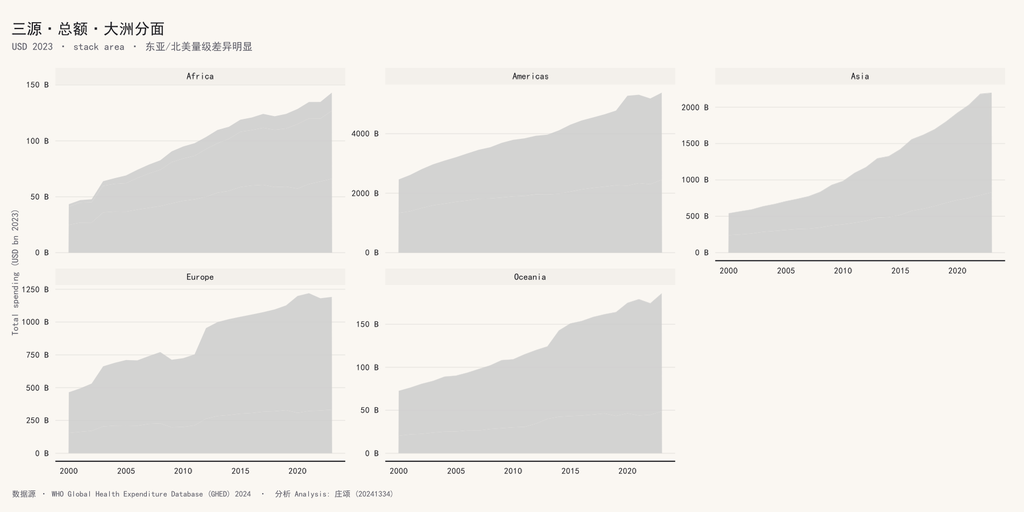

Figure 1B · 大洲分解**按大洲分解的 CHE 流变图**

```r
# =============================================================================
# 程序/07_plot_static.R
# -----------------------------------------------------------------------------
# 静态图工厂函数：输入 tidy tibble，输出 ggplot 对象。
# 所有函数签名：plot_*(data, ..., title, subtitle, caption)
# =============================================================================

if (!exists("proj_root", mode = "function")) {
  source(file.path("程序", "00_utils.R"))
  source(file.path("程序", "06_plot_theme.R"))
}

# =============================================================================
# A. 趋势 / 时序
# =============================================================================

#' 全球三源（政府/私人/外援）占比时序堆叠面积
#'
#' @param master 宽表 (含 gghed_che, pvtd_che, ext_che, year, pop)
plot_source_area <- function(master,
                             title = "\u5168\u7403\u536b\u751f\u652f\u51fa\u6765\u6e90\u7ed3\u6784\u6f14\u5316 Global Health Financing Sources",
                             subtitle = NULL) {
  ensure_pkgs(c("dplyr", "tidyr", "ggplot2", "scales"))
  has_pop <- "pop" %in% names(master) && any(is.finite(master$pop))
  if (is.null(subtitle)) {
    subtitle <- if (has_pop) {
      "2000\u20132023 \u00b7 \u6309\u4eba\u53e3\u52a0\u6743\u5747\u503c\uff0c\u5360\u603b\u5f00\u652f % of CHE"
    } else {
      "2000\u20132023 \u00b7 \u672a\u52a0\u6743\u5747\u503c\uff0c\u5360\u603b\u5f00\u652f % of CHE"
    }
  }
  d <- master |>
    dplyr::group_by(.data$year) |>
    dplyr::summarise(
      gghed = if (has_pop) {
        stats::weighted.mean(.data$gghed_che, .data$pop, na.rm = TRUE)
      } else mean(.data$gghed_che, na.rm = TRUE),
      pvtd  = if (has_pop) {
        stats::weighted.mean(.data$pvtd_che, .data$pop, na.rm = TRUE)
      } else mean(.data$pvtd_che, na.rm = TRUE),
      ext   = if (has_pop) {
        stats::weighted.mean(.data$ext_che, .data$pop, na.rm = TRUE)
      } else mean(.data$ext_che, na.rm = TRUE),
      .groups = "drop"
    ) |>
    tidyr::pivot_longer(c("gghed", "pvtd", "ext"),
                        names_to = "source", values_to = "pct") |>
    dplyr::mutate(source = factor(.data$source, levels = c("gghed", "pvtd", "ext")))
  ggplot2::ggplot(d, ggplot2::aes(.data$year, .data$pct, fill = .data$source)) +
    ggplot2::geom_area(alpha = 0.9, position = "stack") +
    scale_fill_ghs_source(
      labels = c(gghed = "\u653f\u5e9c GGHE-D", pvtd = "\u79c1\u4eba PVT-D", ext = "\u5916\u63f4 EXT")
    ) +
    ggplot2::scale_y_continuous(labels = scales::label_percent(scale = 1)) +
    labs_ghs(
      title = title, subtitle = subtitle,
      x = "\u5e74\u4efd Year", y = "\u5360\u6bd4 Share (%)"
    ) +
    theme_ghs()
}
```

**解读 · 三个分层信号**

**总量层：**全球 CHE 由 2000 年的 $4.68T 增长至 2023 年的 $10.56T，年化 3.60%；人均 CHE 由 $780 升至 $1,328。

**结构层：**政府强制（GGHED）份额在多数高收入国家保持上升；外援（EXT）份额向最贫困国家集中。

**动态层：**2008–2010、 2020–2022 两次冲击在曲线上留下明显凸起，下文 F4 单独分解。

**交互组件 · 跨国人均 CHE 高亮时序线**

本地预览[GitHub 预览](https://github.com/2711944586/R/blob/main/分析输出/交互组件/02_highlight_ts.html)组件中心

**局限 · 小心不要读过量**

- 全球加总受 USD2023 不变价调整，与各国本币发布口径存在领域差异。
- GGHED / PVTD / EXT 占比年代间不严格合计 100%（PVD 与 PHI 定义调整）。
- 该趋势不识别因果，仅描述总量与结构的联动变化。

F2

Finance · 筹资来源

## 谁在付钱：从 OOPS 看财务保护

OOPS 占比是衡量财务风险的核心信号；越高的国家，居民因病致贫的概率越大。

**2023 年 OOPS 均值***30.3%***OOPS > 50% 国家 (2023)***32***GGHED 均值***52.7%*

**研究问题：**谁在为卫生支出买单？政府、居民自付、私人保险与国际外援，各自承担多少风险？

**方法：**使用 financing scheme 维度（hf1–hfnec）的占 CHE 比例。OOPS = hf3_che 是衡量财务保护的核心信号。

OOPS 国家排行（Top10 / Bottom10）

```r
library(dplyr)
rank_oops <- master |>
  dplyr::filter(year == max(year, na.rm = TRUE)) |>
  dplyr::select(country_name, continent, hf3_che, che_pc_usd2023) |>
  dplyr::arrange(dplyr::desc(hf3_che))
utils::head(rank_oops, 10)
```

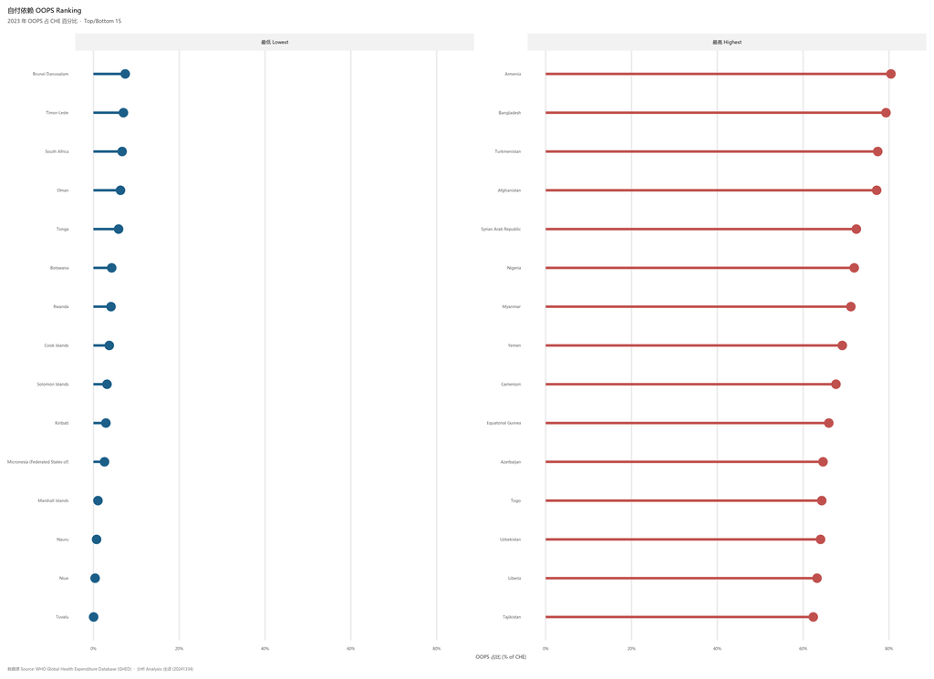

Figure 2A · OOPS 排行**2023 年居民自付占 CHE 国家排行**

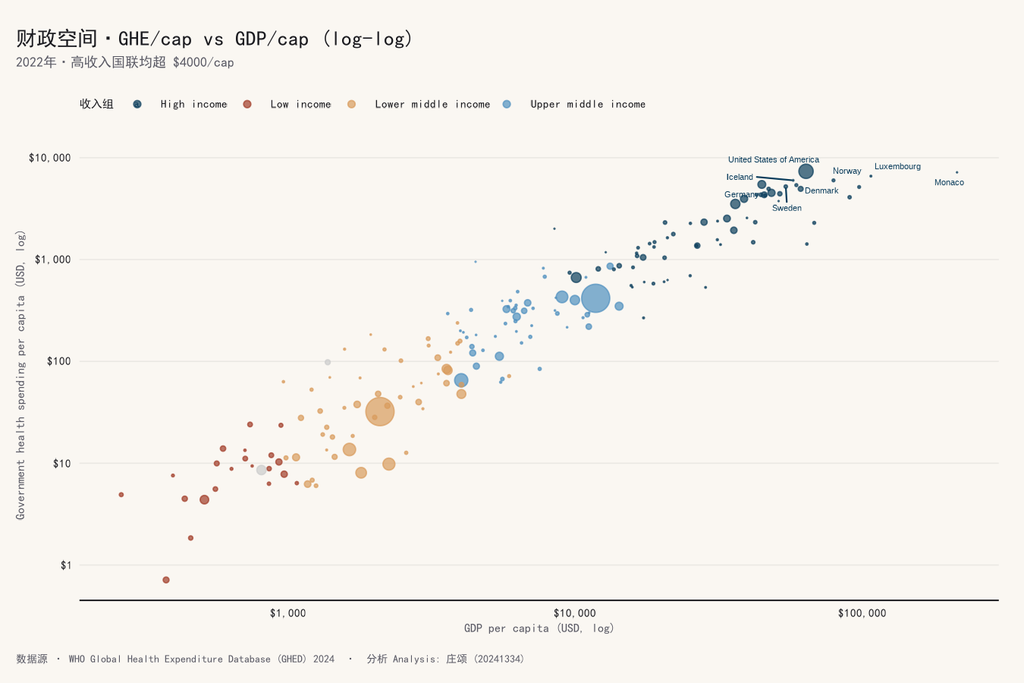

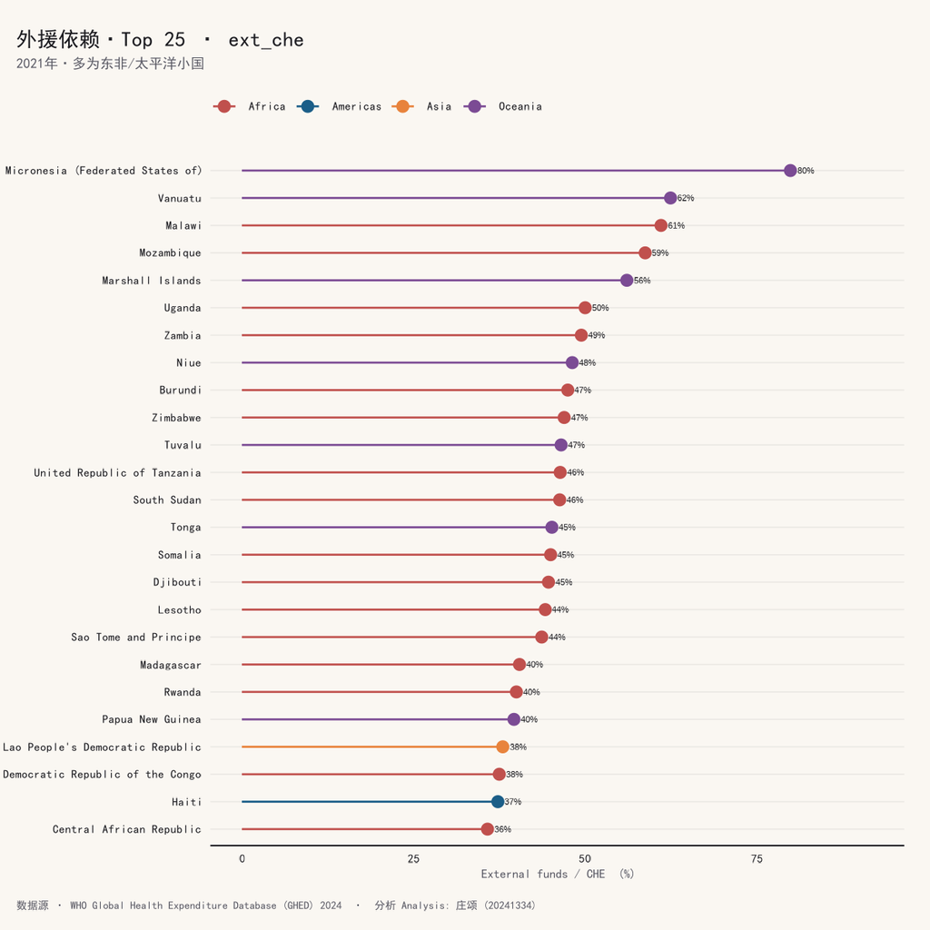

Figure 2C · 外援依赖**外援依赖度：哪些国家 EXT > 20%**

OOPS 最高 8 国（2023）

| 国家/地区 | ISO3 | 大洲 | OOPS 占 CHE (%) | 人均 CHE |
| --- | --- | --- | --- | --- |
| Armenia | ARM | Asia | 80.47 | 761.55 |
| Bangladesh | BGD | Asia | 79.31 | 53.46 |
| Turkmenistan | TKM | Asia | 77.39 | 581.38 |
| Afghanistan | AFG | Asia | 77.14 | 59.07 |
| Syrian Arab Republic | SYR | Asia | 72.40 | 33.34 |
| Nigeria | NGA | Africa | 71.90 | 66.82 |
| Myanmar | MMR | Asia | 71.13 | 56.19 |
| Yemen | YEM | Asia | 69.13 | 47.78 |

OOPS 最低 8 国（2023）

| 国家/地区 | ISO3 | 大洲 | OOPS 占 CHE (%) | 人均 CHE |
| --- | --- | --- | --- | --- |
| Tuvalu | TUV | Oceania | 0.0446 | 1,723.48 |
| Niue | NIU | Oceania | 0.3931 | — |
| Nauru | NRU | Oceania | 0.7317 | 2,292.37 |
| Marshall Islands | MHL | Oceania | 1.05 | 894.22 |
| Micronesia (Federated States of) | FSM | Oceania | 2.58 | 507.78 |
| Kiribati | KIR | Oceania | 2.91 | 238.13 |
| Solomon Islands | SLB | Oceania | 3.16 | 111.36 |
| Cook Islands | COK | Oceania | 3.69 | — |

**解读 · 财务保护与不平等**

**OOPS 集中度：**2023 年仍有 32 个国家 OOPS 高于 50%，主要在南亚、中亚、加勒比与撒哈以南非洲。

**对应关系：**高收入国家 GGHED 高、OOPS 低；外援依赖几乎全出现在 LIC/LMIC。

**政策含义：**提升强制汇集是降低 OOPS 的主要可控变量；外援仅能托底。

**交互组件 · OOPS / GGHED / EXT 可排序表格**

本地预览[GitHub 预览](https://github.com/2711944586/R/blob/main/分析输出/交互组件/12_reactable_rank.html)组件中心

**局限 · 小心不要读过量**

- OOPS 口径依赖于成本分摄调查，部分 LIC 可能偏下。
- 外援 EXT 在人道紧急期会出现年度剧烈跳动。
- 财务保护还受财政货币、医保覆盖面等未入面板变量影响。

F3

Equity · 跨国不平等

## 公平性：Gini / Theil / Atkinson

人口加权后跨国人均 CHE 的不平等长期下降，但绝对水平依然处于极端区间。

**Gini 2000***0.811***Gini 2023***0.772***Theil 2023***1.270*

**研究问题：**跨国人均卫生支出的不平等如何演化？

04_metrics.R · 三个不平等指数的实现

```r
gini_weighted <- function(x, w = NULL) {
  if (is.null(w)) w <- rep(1, length(x))
  ok <- is.finite(x) & is.finite(w) & x >= 0 & w > 0
  x <- x[ok]; w <- w[ok]
  if (length(x) < 2) return(NA_real_)
  ord <- order(x)
  x <- x[ord]; w <- w[ord]
  cum_w <- cumsum(w)
  cum_xw <- cumsum(x * w)
  total_w <- sum(w); total_xw <- sum(x * w)
  if (total_xw == 0) return(0)
  g <- 1 - 2 * sum((cum_xw - x * w / 2) * w) / (total_w * total_xw)
  g
}

#' Theil-T 指数（人口加权）
theil_t <- function(x, w = NULL) {
  if (is.null(w)) w <- rep(1, length(x))
  ok <- is.finite(x) & is.finite(w) & x > 0 & w > 0
  x <- x[ok]; w <- w[ok]
  if (length(x) < 2) return(NA_real_)
  mean_x <- stats::weighted.mean(x, w)
  if (mean_x == 0) return(0)
  sum(w * x / sum(w * x) * log(x / mean_x))
}

#' Atkinson 指数 (ε)
atkinson <- function(x, w = NULL, eps = 0.5) {
  if (is.null(w)) w <- rep(1, length(x))
  ok <- is.finite(x) & is.finite(w) & x > 0 & w > 0
  x <- x[ok]; w <- w[ok]
  if (length(x) < 2) return(NA_real_)
  mean_x <- stats::weighted.mean(x, w)
  if (eps == 1) {
    ede <- exp(stats::weighted.mean(log(x), w))
  } else {
    ede <- (stats::weighted.mean(x^(1 - eps), w))^(1 / (1 - eps))
  }
  1 - ede / mean_x
}

# ---- 2. 时间序列的不平等 ---------------------------------------------------
#' 按 year 计算全球人均 CHE 的不平等指数面板
inequality_by_year <- function(master, value_col = "che_pc_usd2023",
                               weight_col = "pop") {
  ensure_pkgs(c("dplyr", "tidyr", "tibble"))
  val <- rlang::sym(value_col)
  wgt <- rlang::sym(weight_col)
  master |>
    dplyr::filter(
      is.finite(!!val), !!val > 0,
      is.finite(!!wgt) | TRUE
    ) |>
    dplyr::group_by(.data$year) |>
    dplyr::summarise(
      n            = dplyr::n(),
      gini_eq      = gini_weighted(!!val, NULL),
      gini_pop     = if (weight_col %in% names(master)) {
        gini_weighted(!!val, !!wgt)
      } else NA_real_,
      theil_pop    = if (weight_col %in% names(master)) {
        theil_t(!!val, !!wgt)
      } else NA_real_,
      atk05        = atkinson(!!val, NULL, eps = 0.5),
      atk1         = atkinson(!!val, NULL, eps = 1),
      mean_val     = mean(!!val, na.rm = TRUE),
      median_val   = median(!!val, na.rm = TRUE),
      .groups      = "drop"
    )
}
```

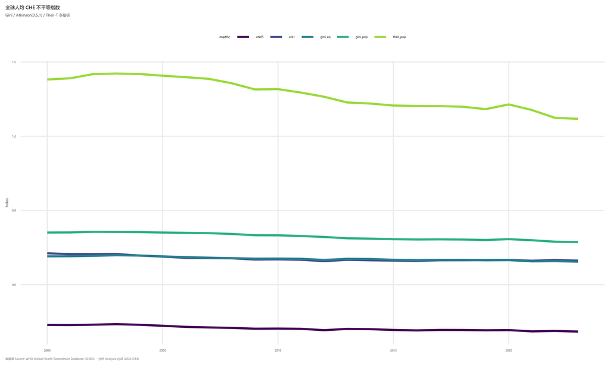

Figure 3A · 不平等时序**Gini / Theil / Atkinson 三指标长期演化**

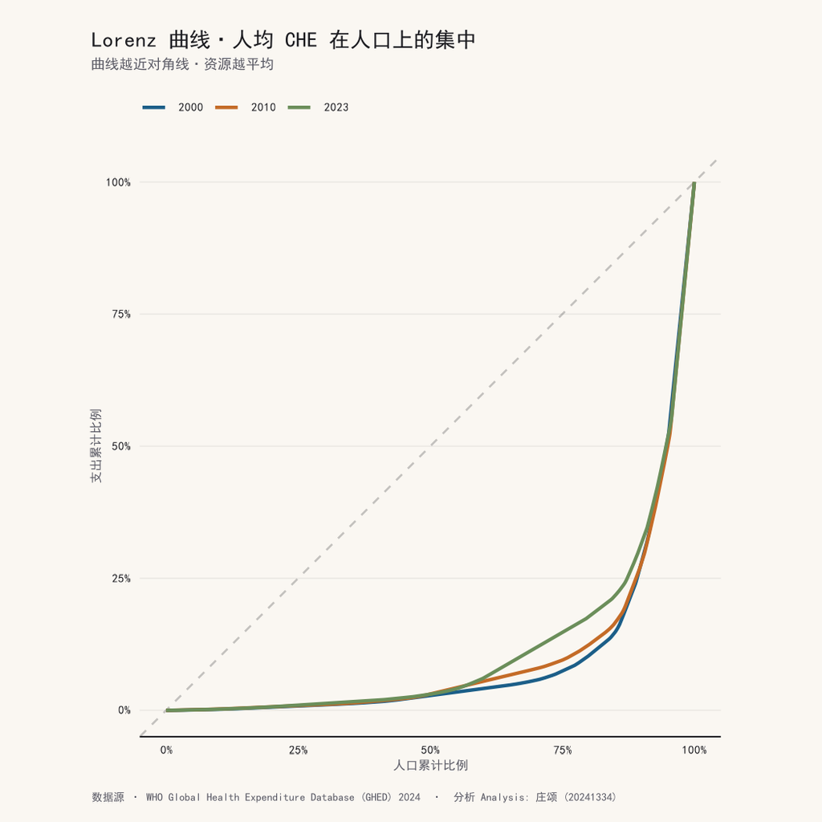

Figure 3B · 洛伦兹曲线**洛伦兹曲线：2000 vs 2023**

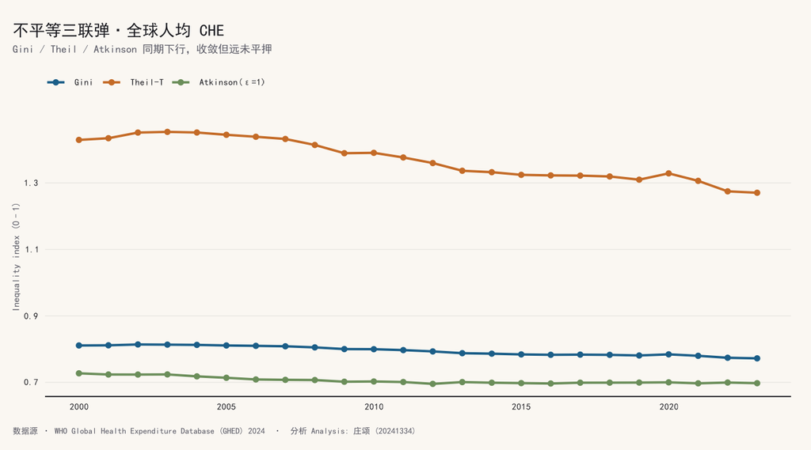

Figure 3C · 多指标对比**不平等指数面板**

近 8 年不平等指数

| 年份 | Gini(pop) | Theil-T | Atk 0.5 | Atk 1.0 | 人均均值 | 人均中位 |
| --- | --- | --- | --- | --- | --- | --- |
| 2,023.000 | 0.77223 | 1.270 | 0.41087 | 0.69750 | 1,428.917 | 470.403 |
| 2,022.000 | 0.77398 | 1.275 | 0.41329 | 0.69947 | 1,419.500 | 457.055 |
| 2,021.000 | 0.77988 | 1.306 | 0.41166 | 0.69708 | 1,450.204 | 466.051 |
| 2,020.000 | 0.78426 | 1.329 | 0.41681 | 0.70008 | 1,399.897 | 412.816 |
| 2,019.000 | 0.78087 | 1.310 | 0.41600 | 0.69938 | 1,341.262 | 412.571 |
| 2,018.000 | 0.78274 | 1.319 | 0.41726 | 0.69913 | 1,299.590 | 398.971 |
| 2,017.000 | 0.78341 | 1.322 | 0.41740 | 0.69899 | 1,291.563 | 395.831 |
| 2,016.000 | 0.78289 | 1.323 | 0.41551 | 0.69657 | 1,286.138 | 395.578 |

**解读 · 平均上升 / 不平等下降的悶论**

**结构性下降：**人口加权 Gini 由 2000 年的约 0.811 降至 2023 年的约 0.772；并非来自富国停滞，而是中、印、印尼等大国人均 CHE 快速上升。

**剩余不平等仍极高：**0.77 的 Gini 仍处于全球收入分配的极端区间。

**三指标互补：**Atkinson(ε=1) 长期高于 0.69，提示底层敏感的不平等下降幅度更小。

**交互组件 · 不平等三指标交互趋势**

本地预览[GitHub 预览](https://github.com/2711944586/R/blob/main/分析输出/交互组件/07_inequality.html)组件中心

**局限 · 小心不要读过量**

- Gini 与 Theil 在极端重尾分布下估计偏差受样本大小影响。
- Atkinson 取 ε = 0.5 与 ε = 1.0 反映不同偏好，需同时报呈。
- 跨国不平等 ≠ 国内不平等；后者需 LSMS / DHS 微观样本。

F4

Resilience · 危机冲击

## 新冠冲击：被压缩的财政与转移的负担

COVID-19 暴露了卫生体系的脆弱性，但不同国家承担危机成本的方式截然不同。

**研究问题：**新冠大流行期间，哪些国家显著增加了卫生支出？哪些反而萎缩？

**方法：**定义 base = 2019、shock = 2020–2022 平均；对每个国家计算 CHE 相对变化与 OOPS 百分点变化。

04_metrics.R · COVID 冲击度量

```r
covid_shock <- function(master, base_year = 2019,
                        shock_years = 2020:2022) {
  ensure_pkgs("dplyr")
  master |>
    dplyr::filter(.data$year %in% c(base_year, shock_years)) |>
    dplyr::mutate(
      phase = dplyr::if_else(.data$year == base_year, "base", "shock")
    ) |>
    dplyr::group_by(.data$iso3_code, .data$country_name) |>
    dplyr::summarise(
      base_che    = mean(.data$che_usd2023[.data$phase == "base"], na.rm = TRUE),
      shock_che   = mean(.data$che_usd2023[.data$phase == "shock"], na.rm = TRUE),
      base_oops   = mean(.data$hf3_che[.data$phase == "base"], na.rm = TRUE),
      shock_oops  = mean(.data$hf3_che[.data$phase == "shock"], na.rm = TRUE),
      base_gghed  = mean(.data$gghed_che[.data$phase == "base"], na.rm = TRUE),
      shock_gghed = mean(.data$gghed_che[.data$phase == "shock"], na.rm = TRUE),
      .groups     = "drop"
    ) |>
    dplyr::mutate(
      che_delta_pct   = (.data$shock_che  - .data$base_che)  / .data$base_che  * 100,
      oops_delta_pp   =  .data$shock_oops - .data$base_oops,
      gghed_delta_pp  =  .data$shock_gghed - .data$base_gghed
    )
}
```

[figure not shown]

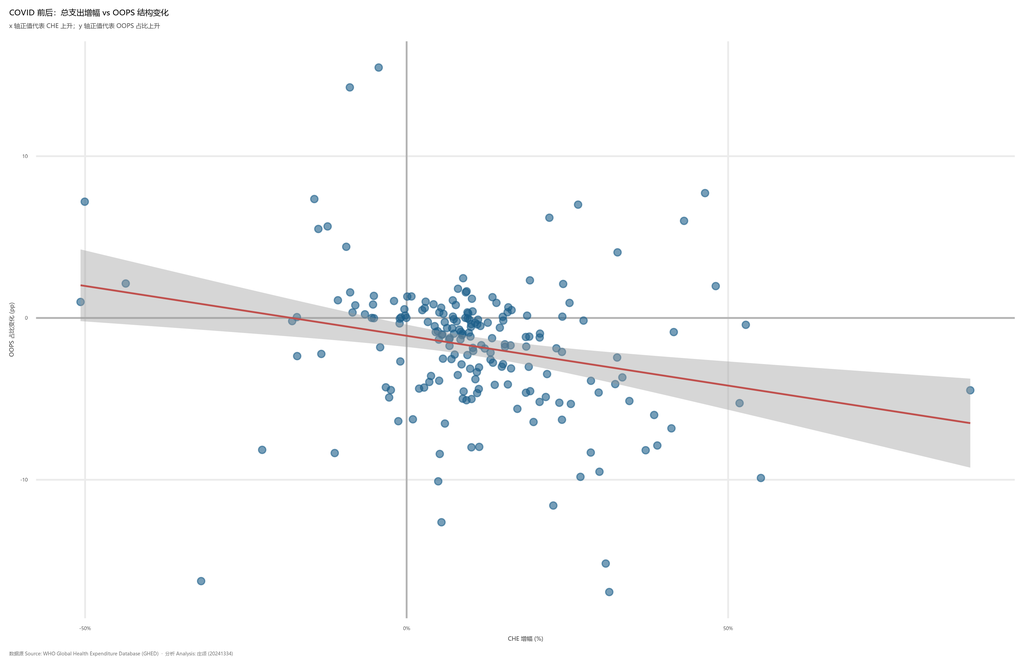

Figure 4B · CHE 与 OOPS 联动**CHE 增量 vs OOPS 增量散点**

CHE 相对变化最大的 8 个国家

| 国家/地区 | ISO3 | 2019 基线 CHE | 2020–2022 平均 CHE | 相对变化 |
| --- | --- | --- | --- | --- |
| Timor-Leste | TLS | $108.02M | $202.70M | 87.66% |
| Guyana | GUY | $220.41M | $341.84M | 55.09% |
| Niue | NIU | $2.37M | $3.62M | 52.75% |
| Mongolia | MNG | $834.74M | $1.27B | 51.77% |
| Uzbekistan | UZB | $3.97B | $5.88B | 48.07% |
| Liberia | LBR | $351.12M | $514.06M | 46.41% |
| Burkina Faso | BFA | $993.83M | $1.42B | 43.14% |
| Cook Islands | COK | $11.98M | $16.96M | 41.54% |

**解读 · 危机中的两类轨迹**

**政府托底型：**多数 OECD 国家 CHE 抬升、GGHED 上升，OOPS 反而下降。

**财政紧缩型：**部分中低收入国家 CHE 名义抬升但 OOPS 同步上升，意味着抬升主要来自居民自付。

**政策含义：**在常态预算外预设反周期卫生缓冲。

**交互组件 · OOPS 2019 vs 2020-2022 热力图**

本地预览[GitHub 预览](https://github.com/2711944586/R/blob/main/分析输出/交互组件/v2_w_oops_heatmap.html)组件中心

**局限 · 小心不要读过量**

- 2020–2022 均值与 2019 基线对比仅捕捉短期冲击。
- 部分国家 2022–2023 数据仍为初估，存在修正风险。
- 未及 COVID 主动付费后续调整（如报销、补贴、交叉补偿）。

F5

Convergence · 收敛

## β-收敛：贫国是否在追赶？

把 23 年人均 CHE 增速拟合到起点水平，结果支持 β-收敛但分大洲存在显著异质性。

**β (log y₀)***-0.0085***半收敛年***81.2***R²***0.215*

**研究问题：**低水平国家是否在追赶高水平国家？

**方法：**构造截面：每国 2000 与 2023 的人均 CHE；计算年化对数增速；以 continent 为固定效应，回归 growth ~ log y₀。

拟合结果：β = -0.0085，半收敛年 ≈ 81.2 年；β < 0 即支持收敛假设。

05_models.R · β-收敛回归

```r
#' log(人均 CHE) 增速 ~ log(起始水平) + 固定效应
#' 输入：master 宽表（含 iso3_code, year, che_pc_usd2023, continent）
fit_beta_convergence <- function(master, start_year = 2000, end_year = 2023) {
  ensure_pkgs(c("dplyr"))
  if (!requireNamespace("fixest", quietly = TRUE)) {
    warning("fixest not installed; beta-convergence skipped")
    return(NULL)
  }
  panel <- master |>
    dplyr::filter(.data$year %in% c(start_year, end_year),
                  is.finite(.data$che_pc_usd2023),
                  .data$che_pc_usd2023 > 0) |>
    dplyr::select("iso3_code", "continent", "year", "che_pc_usd2023") |>
    tidyr::pivot_wider(names_from = "year", values_from = "che_pc_usd2023",
                       names_prefix = "y_") |>
    tidyr::drop_na() |>
    dplyr::mutate(
      log_start  = log(!!rlang::sym(paste0("y_", start_year))),
      log_end    = log(!!rlang::sym(paste0("y_", end_year))),
      growth     = (.data$log_end - .data$log_start) / (end_year - start_year)
    )
  if (nrow(panel) < 10) return(NULL)
  mod <- tryCatch(
    fixest::feols(growth ~ log_start | continent, data = panel),
    error = function(e) lm(growth ~ log_start + continent, data = panel)
  )
  list(
    panel = panel,
    model = mod,
    beta  = stats::coef(mod)[["log_start"]],
    half_life = if ("log_start" %in% names(stats::coef(mod))) {
      -log(2) / stats::coef(mod)[["log_start"]]
    } else NA_real_
  )
}
```

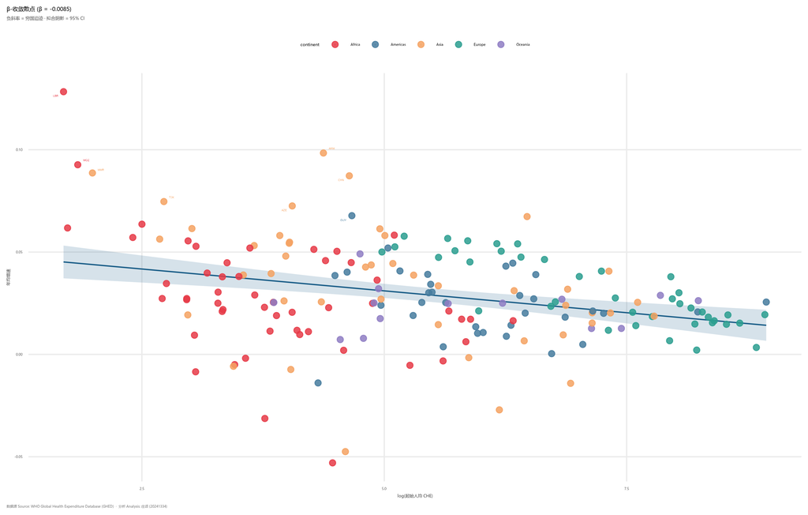

Figure 5 · β-收敛**β-收敛散点 + 回归线**

**解读 · 收敛与异质性**

**整体收敛：**β 显著为负，起点越低过去 23 年人均 CHE 增速越快。

**大洲差异：**非洲国家平均增速最高，但起点最低，半收敛年最长。

**含义：**追赶不是自动的；需要持续的 GGHED 投入与外部技术援助。

**交互组件 · GDP × CHE_pc × 人口气泡 (gapminder)**

本地预览[GitHub 预览](https://github.com/2711944586/R/blob/main/分析输出/交互组件/v2_w_gapminder_bubble.html)组件中心

**局限 · 小心不要读过量**

- 经典 β-收敛只描述平均趋势，心中与低位间距仍有开。
- continent 固定效应只控制领域面，未控制个体 / 制度面变量。
- 起点 2000 年部分 LIC 存在数据缺失，需以 enrich 补齐。

F6

Modeling · 弹性估计

## GDP ↔ 卫生支出弹性：双向 FE

在控制国家与年份固定效应后，人均卫生支出对 GDP 的弹性接近 0.8。

**弹性 β̂***0.798***标准误***0.067***t-stat***11.86*

**研究问题：**当一国 GDP 上升 1%，其人均卫生支出大约上升多少？

**方法：**用 fixest::feols 拟合双向固定效应：log(che_pc_usd2023) ~ log(gdp_pc_usd) | iso3_code + year，按国家聚类标准误。

05_models.R · 面板双向固定效应

```r
#' log(人均 CHE) ~ log(GDP/cap) + income_group | country + year
fit_panel_fe <- function(master) {
  ensure_pkgs("dplyr")
  if (!requireNamespace("fixest", quietly = TRUE)) {
    warning("fixest not installed; returning NULL")
    return(NULL)
  }
  dat <- master |>
    dplyr::filter(is.finite(.data$che_pc_usd2023), .data$che_pc_usd2023 > 0,
                  is.finite(.data$gdp_pc_usd),      .data$gdp_pc_usd > 0) |>
    dplyr::mutate(
      log_che_pc = log(.data$che_pc_usd2023),
      log_gdp_pc = log(.data$gdp_pc_usd)
    )
  if (nrow(dat) < 100) return(NULL)
  tryCatch(
    fixest::feols(log_che_pc ~ log_gdp_pc | iso3_code + year, data = dat,
                  cluster = ~iso3_code),
    error = function(e) NULL
  )
}
```

回归结果（按 iso3 聚类标准误）

| 变量 | 估计值 | 标准误 | t 值 | p 值 |
| --- | --- | --- | --- | --- |
| log_gdp_pc | 0.797860 | 0.067275 | 11.8597 | 0.000000 |

**解读 · 弹性接近 0.8**

**主结论：**GDP 每上升 1%，人均 CHE 上升约 0.8%，弹性显著小于 1。

**含义：**纯粋依靠经济增长来扩大卫生支出是不够的；财政空间需要主动制度安排。

**交互组件 · 多变量散点矩阵 (SPLOM)**

本地预览[GitHub 预览](https://github.com/2711944586/R/blob/main/分析输出/交互组件/v2_w_splom.html)组件中心

**局限 · 小心不要读过量**

- FE 仅控面不可观测且不随时间变化的项，不代表因果。
- 未加入人口老龄化、默克尔指数等可能控变量。
- 聚类标准误与年代限制为推断设计选择，可能偏低。

F7

Typology · 国家组合

## PCA 与聚类：四种典型筹资 archetype

在 financing 结构空间里，全球国家自然分成 4 类，每类有不同的政策重点。

**研究问题：**把国家放在筹资结构空间（GGHED · PVTD · EXT · OOPS），它们能聚成几个 archetype？

05_models.R · PCA + k-means

```r
fit_pca <- function(df, vars, scale = TRUE) {
  ensure_pkgs(c("dplyr"))
  keep <- df |>
    dplyr::select(dplyr::all_of(c("iso3_code", "country_name", vars))) |>
    tidyr::drop_na()
  if (nrow(keep) < 5) {
    warning("PCA: fewer than 5 complete observations; returning NULL")
    return(NULL)
  }
  X <- as.matrix(keep[, vars, drop = FALSE])
  rownames(X) <- keep$iso3_code
  pca <- stats::prcomp(X, center = TRUE, scale. = scale)
  list(
    pca    = pca,
    scores = as.data.frame(pca$x) |>
      tibble::rownames_to_column("iso3_code") |>
      dplyr::left_join(keep[, c("iso3_code", "country_name")], by = "iso3_code"),
    loadings = as.data.frame(pca$rotation) |> tibble::rownames_to_column("variable"),
    var_explained = summary(pca)$importance["Proportion of Variance", ]
  )
}

# ---- 2. k-means 聚类 --------------------------------------------------------
#' 在 PCA 前两主成分上做 k-means
fit_cluster <- function(pca_obj, k = 4, seed = 1L) {
  if (is.null(pca_obj)) return(NULL)
  set.seed(seed)
  X <- pca_obj$scores[, grep("^PC", names(pca_obj$scores))]
  if (ncol(X) < 2) {
    warning("cluster: need at least 2 PCs")
    return(NULL)
  }
  km <- stats::kmeans(X[, 1:min(ncol(X), 5)], centers = k, nstart = 25)
  scores <- pca_obj$scores
  scores$cluster <- factor(km$cluster)
  list(km = km, scores = scores, k = k)
}
```

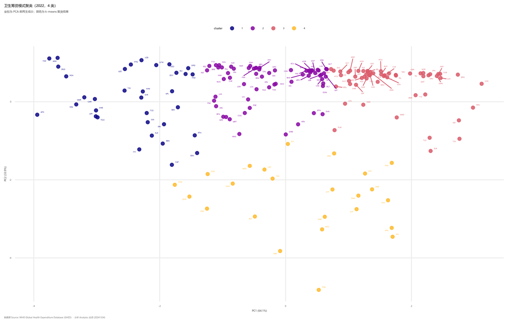

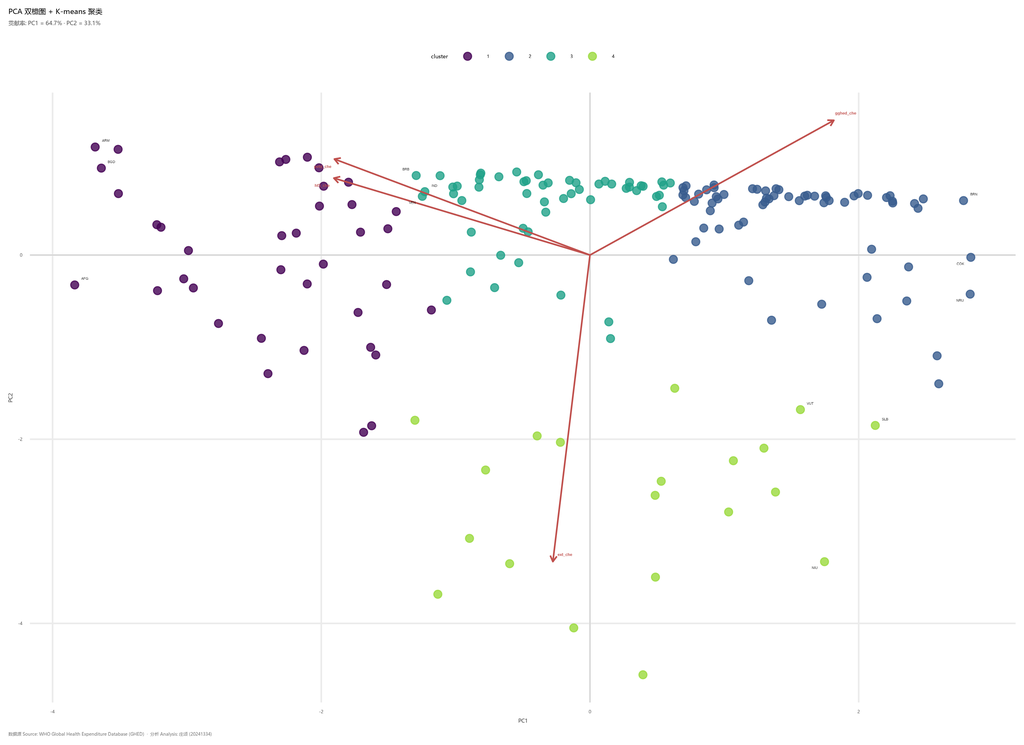

Figure 7B · 主成分载荷**PCA 主成分载荷（financing 维度）**

**解读 · 4 类典型 archetype**

**A · 政府强主导：**欧洲 + 部分东亚高收入国家，GGHED > 70%。

**B · 私人保险型：**美国为典型；PVTD 与 OOPS 均高。

**C · 自付驱动型：**南亚、中亚国家；OOPS > 40%，财务保护薄弱。

**D · 外援依赖型：**撒哈以南非洲低收入国家；EXT 占比显著。

**交互组件 · PCA 附近联网·国家 archetype**

本地预览[GitHub 预览](https://github.com/2711944586/R/blob/main/分析输出/交互组件/v2_w_country_network.html)组件中心

**局限 · 小心不要读过量**

- PCA 主成分载荷依赖变量选择；加入 / 去除 EXT 与 PVTD 会改变双众 plot。
- k = 4 为使用 elbow + silhouette 联合选取；不代表唯一能选择。
- 聚类仅描述截面状态，动态转移路径需 longitudinal cluster。

F8

Forecast · 5 年外推

## ARIMA 预测：四国 2024–2028

auto.arima 对中、美、印、巴的人均 CHE 给出短期延续上升的判断。

**方法***ARIMA(auto)***预测年限***5 年***覆盖国家***CHN · USA · IND · BRA*

**研究问题：**2024–2028 中、美、印、巴的人均卫生支出会朝哪个方向走？

**方法：**对每国 2000–2023 的 che_pc_usd2023 序列拟合 auto.arima，输出 5 年点预测与 80%/95% 区间。

05_models.R · ARIMA 预测

```r
#' 用 fable 或 forecast 对一国一指标做 h 期预测
fit_forecast <- function(ts_vec, years, h = 5, method = c("auto", "prophet")) {
  method <- match.arg(method)
  ts_vec <- as.numeric(ts_vec)
  ok <- is.finite(ts_vec)
  if (sum(ok) < 5) return(NULL)
  ts_vec <- ts_vec[ok]; years <- years[ok]
  if (method == "auto" && requireNamespace("forecast", quietly = TRUE)) {
    ts_obj <- stats::ts(ts_vec, start = min(years), frequency = 1)
    fit <- tryCatch(forecast::auto.arima(ts_obj), error = function(e) NULL)
    if (is.null(fit)) return(NULL)
    fc <- forecast::forecast(fit, h = h)
    return(tibble::tibble(
      year  = (max(years) + 1):(max(years) + h),
      point = as.numeric(fc$mean),
      lo_80 = as.numeric(fc$lower[, 1]),
      hi_80 = as.numeric(fc$upper[, 1]),
      lo_95 = as.numeric(fc$lower[, 2]),
      hi_95 = as.numeric(fc$upper[, 2]),
      method = "ARIMA"
    ))
  }
  if (method == "prophet" && requireNamespace("prophet", quietly = TRUE)) {
    dfp <- data.frame(
      ds = as.Date(paste0(years, "-01-01")),
      y  = ts_vec
    )
    m <- tryCatch(
      prophet::prophet(dfp, yearly.seasonality = FALSE, weekly.seasonality = FALSE,
                       daily.seasonality = FALSE, verbose = FALSE),
      error = function(e) NULL
    )
    if (is.null(m)) return(NULL)
    future <- prophet::make_future_dataframe(m, periods = h, freq = "year")
    pred <- stats::predict(m, future)
    tail_n <- utils::tail(pred, h)
    return(tibble::tibble(
      year  = as.integer(format(tail_n$ds, "%Y")),
      point = tail_n$yhat,
      lo_80 = tail_n$yhat_lower,
      hi_80 = tail_n$yhat_upper,
      lo_95 = tail_n$yhat_lower,
      hi_95 = tail_n$yhat_upper,
      method = "Prophet"
    ))
  }
  NULL
}
```

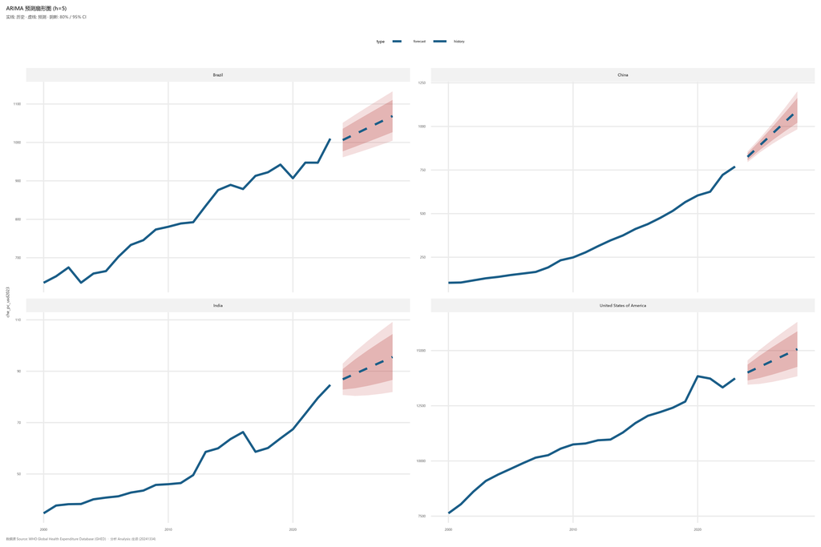

Figure 8 · 预测扇形**5 年 ARIMA 预测扇形图**

5 年预测明细

| 国家 | 年份 | 点估计 | 80% 区间 | 方法 |
| --- | --- | --- | --- | --- |
| China | 2,024.00 | 825.59 | [805.4, 845.8] | ARIMA |
| China | 2,025.00 | 892.26 | [865.5, 919.0] | ARIMA |
| China | 2,026.00 | 958.93 | [920.7, 997.2] | ARIMA |
| China | 2,027.00 | 1,025.61 | [972.3, 1,079.0] | ARIMA |
| China | 2,028.00 | 1,092.28 | [1,021.2, 1,163.4] | ARIMA |
| United States of America | 2,024.00 | 14,005.73 | [13,645.4, 14,366.0] | ARIMA |
| United States of America | 2,025.00 | 14,271.41 | [13,761.9, 14,780.9] | ARIMA |
| United States of America | 2,026.00 | 14,537.09 | [13,913.1, 15,161.1] | ARIMA |
| United States of America | 2,027.00 | 14,802.77 | [14,082.2, 15,523.3] | ARIMA |
| United States of America | 2,028.00 | 15,068.45 | [14,262.8, 15,874.1] | ARIMA |
| India | 2,024.00 | 86.86 | [82.9, 90.9] | ARIMA |
| India | 2,025.00 | 89.03 | [83.4, 94.7] | ARIMA |
| India | 2,026.00 | 91.21 | [84.3, 98.1] | ARIMA |
| India | 2,027.00 | 93.38 | [85.4, 101.4] | ARIMA |
| India | 2,028.00 | 95.55 | [86.6, 104.5] | ARIMA |
| Brazil | 2,024.00 | 1,006.18 | [976.8, 1,035.5] | ARIMA |
| Brazil | 2,025.00 | 1,021.80 | [988.8, 1,054.8] | ARIMA |
| Brazil | 2,026.00 | 1,037.41 | [1,001.2, 1,073.6] | ARIMA |
| Brazil | 2,027.00 | 1,053.03 | [1,013.8, 1,092.2] | ARIMA |
| Brazil | 2,028.00 | 1,068.64 | [1,026.7, 1,110.6] | ARIMA |

**解读 · 预测的边界**

**趋势延续：**四国均维持上升趋势，中、印相对增速最大。

**不确定性带：**外推 5 年后区间快速发散。

**建议：**结合 Shiny 仪表盘 Scenarios 模块做情景推演。

**交互组件 · 4 国 ARIMA 交互子图**

本地预览[GitHub 预览](https://github.com/2711944586/R/blob/main/分析输出/交互组件/06_forecast_subplot.html)组件中心

**局限 · 小心不要读过量**

- ARIMA 是单变量时序，不控 GDP · 财政 · 老龄化等驱动项。
- 5 年以上外推使 80% 区间快速发散，需谨慎引用。
- 未插入重大冲击（另一大流行、金融危机）的场景损动。

F9

Aid · 外援依赖

## 谁靠外援：外部依赖与本土财政的二分法

EXT 占 CHE 超过 20% 意味着本土财政难以独立支撑系统；该信号与 OOPS 并存提示居民仍需按次付费。

**研究问题：**哪些国家的卫生财务难以脱离外援？外援占比与财务保护（OOPS）是如何联动的？

**方法：**取 GHED financing source 中的 EXT (External transfer schemes) 占 CHE 份额，跨联 OOPS / GGHED 与人均 CHE，重点识别哪些 LIC 仍处于输血型阶段。

EXT > 20% 高依赖国家排行

```r
library(dplyr)
aid_rank <- master |>
  dplyr::filter(year == max(year, na.rm = TRUE)) |>
  dplyr::select(country_name, continent, ext_che, gghed_che, hf3_che, che_pc_usd2023) |>
  dplyr::arrange(dplyr::desc(ext_che))
head(aid_rank, 10)
```

[output not shown]

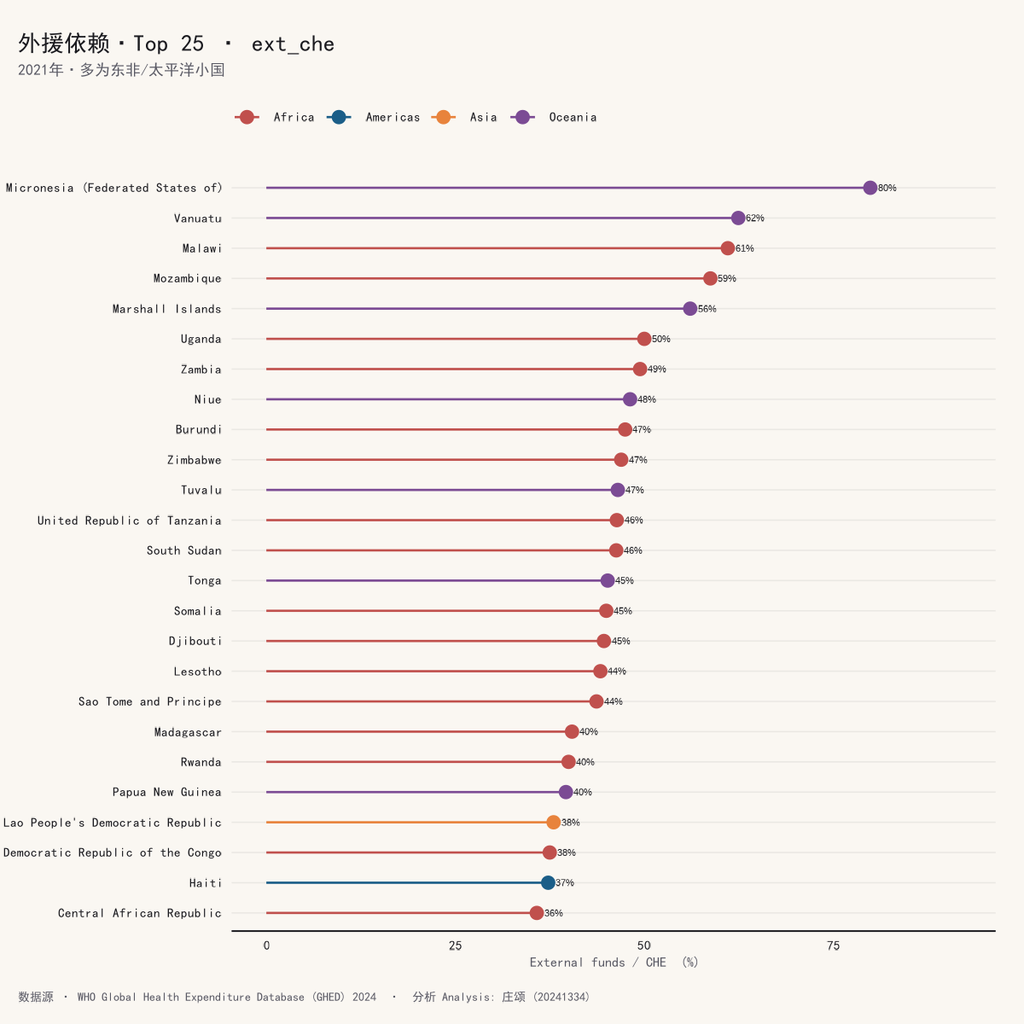

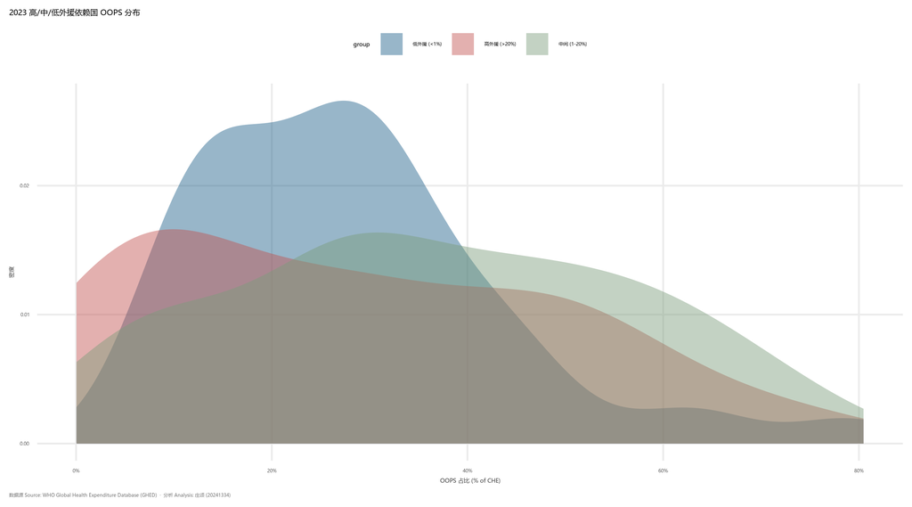

EXT 依赖度最高的 8 个国家 (2023)

| 国家/地区 | ISO3 | 大洲 | EXT 占 CHE (%) | 人均 CHE | GGHED 占 CHE (%) |
| --- | --- | --- | --- | --- | --- |
| Micronesia (Federated States of) | FSM | Oceania | 71.47 | 507.78 | 14.23 |
| Malawi | MWI | Africa | 65.50 | 41.27 | 12.82 |
| South Sudan | SSD | Africa | 62.30 | 72.76 | 4.32 |
| Mozambique | MOZ | Africa | 57.71 | 52.96 | 26.46 |
| Burundi | BDI | Africa | 57.42 | 28.14 | 14.74 |
| Somalia | SOM | Africa | 54.41 | 22.37 | 14.17 |
| Niue | NIU | Oceania | 54.37 | — | 45.23 |
| Zambia | ZMB | Africa | 47.91 | 79.56 | 40.72 |

**解读 · 外援仅能托底**

**集中于低收入：**2023 年仍有 36 个国家 EXT > 20%，全部为 LIC/LMIC。

**路径：**需同步推动本土财政强制汇集、社医隐性价、PHC 初诊补偿。

**交互组件 · GGHED / PVTD / EXT / OOPS 资金流 sankey**

本地预览[GitHub 预览](https://github.com/2711944586/R/blob/main/分析输出/交互组件/v2_w_sankey_flows.html)组件中心

**局限 · 小心不要读过量**

- EXT 调查存在跳变；2020–2022 人道响应抬升使部分国家外援份额临时高估。
- GHED 未能完全覆盖双边·全球基金与领备报销不对称。
- EXT 占比仅反映资金来源，不代表资金效率。

F10

Efficiency · 资金 · 寿命

## 同样人均 CHE，谁走在效率前沿？

在给定人均资金下，各国预期寿命 / U5MR 的差异右反映体系质量、PHC 、社医覆盖面等非资金因素。

**拟合斜率***3.57***R²***0.685***可用国家***191*

**研究问题：**同样人均 CHE 下，哪些国家“花得更加划算”（预期寿命高于预测值）？

**方法：**拟合 预期寿命 ~ log(人均 CHE)，取正残差作为“起动效率领先者”代理；与 DEA 输出不同但思路互补。 拟合预期寿命 ~ log(人均 CHE)：人均资金每变为 e 倍 (≈2.72 倍) 联动预期寿命增加 3.57 年，R² = 0.685。

“花多越多、但不一定买到寿命” · 简析拟合

```r
library(dplyr)
fit <- master |>
  dplyr::filter(year == max(year, na.rm = TRUE),
                is.finite(che_pc_usd2023), is.finite(life_exp)) |>
  lm(life_exp ~ log(che_pc_usd2023), data = _)
summary(fit)
```

[output not shown]

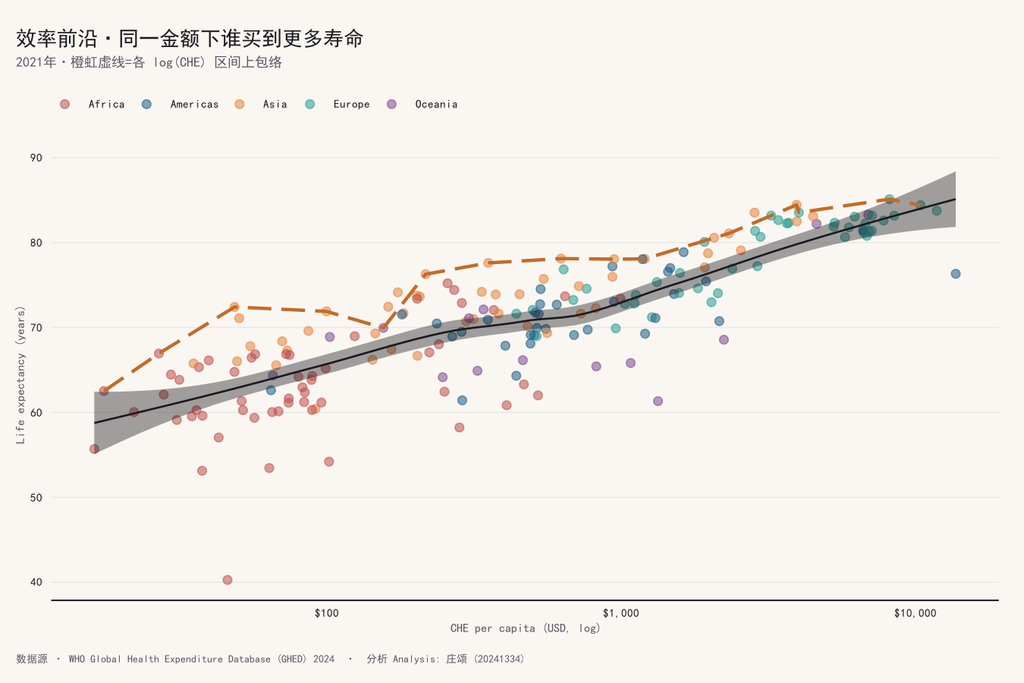

Figure 10A · 效率前沿**DEA 效率前沿：人均 CHE · U5MR / 预期寿命**

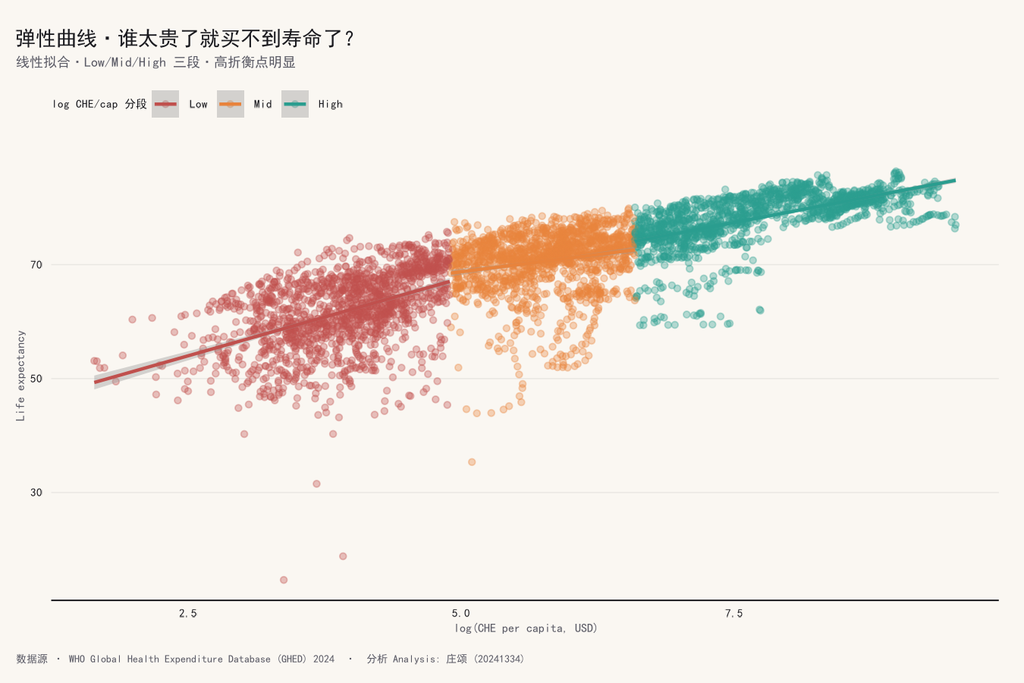

Figure 10B · 输入 · 输出**人均 CHE 与 预期寿命 / U5MR 的弹性**

预期寿命高于人均 CHE 预测最多的 8 个国家（高效率象限）

| 国家 | ISO3 | 大洲 | 人均 CHE | 预期寿命 | 残差 |
| --- | --- | --- | --- | --- | --- |
| Bangladesh | BGD | Asia | 53.464 | 74.672 | 9.048 |
| Sri Lanka | LKA | Asia | 139.930 | 77.483 | 8.423 |
| Syrian Arab Republic | SYR | Asia | 33.340 | 72.120 | 8.183 |
| Lebanon | LBN | Asia | 260.812 | 77.817 | 6.533 |
| Iran (Islamic Republic of) | IRN | Asia | 267.059 | 77.654 | 6.286 |
| Lao People's Democratic Republic | LAO | Asia | 27.418 | 68.964 | 5.725 |
| Jordan | JOR | Asia | 342.104 | 77.814 | 5.561 |
| Algeria | DZA | Africa | 233.379 | 76.261 | 5.374 |

**解读 · 资金不等于成效**

**低效率老足不才：**部分中东 · 中亚 · 拉美 人均 CHE 较高但预期寿命低于预测。

**交互组件 · DEA · ARIMA · Lorenz 联动场景**

本地预览[GitHub 预览](https://github.com/2711944586/R/blob/main/分析输出/交互组件/v2_w_scenarios.html)组件中心

**局限 · 小心不要读过量**

- 预期寿命是多因素结果，不仅取决于卫生支出。
- 跨国备价受到 PPP / 物价·人口构·集达代价差异影响。
- 折不使用多输入 DEA（仅 1 输入 · 1 输出）。

S20 · Country Profiles

## 四个代表性国家档案

以中 · 美 · 印 · 巴为例，呈现不同 archetype 在趋势、筹资结构、财务保护与外部依赖上的差异。

CHN

### China

Asia · 2000–2023

**人均 CHE***$770***CHE 年化***9.64%***OOPS***32.2%***GGHED***57.1%***EXT***0.0%***人口***$1.41B*

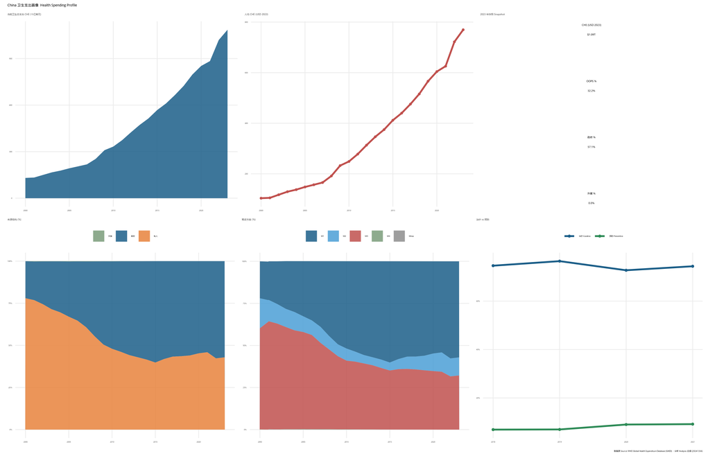

Profile · CHN**China · 国家面板**

China · 面板节选 2000 / 2018 / 2023

| 年 | 人均 CHE | CHE 总额 | GGHED % | PVTD % | EXT % | OOPS % | 人口 |
| --- | --- | --- | --- | --- | --- | --- | --- |
| 2,000.00 | 103.47 | $130.65B | 21.98 | 78.00 | 0.0255 | 60.13 | $1.26B |
| 2,018.00 | 515.71 | $723.42B | 56.42 | 43.58 | 6e-04 | 35.75 | $1.40B |
| 2,023.00 | 769.80 | $1.09T | 57.10 | 42.90 | 0.0051 | 32.17 | $1.41B |

USA

### United States of America

Americas · 2000–2023

**人均 CHE***$13,740***CHE 年化***3.38%***OOPS***10.9%***GGHED***54.0%***EXT***0.0%***人口***$336.81M*

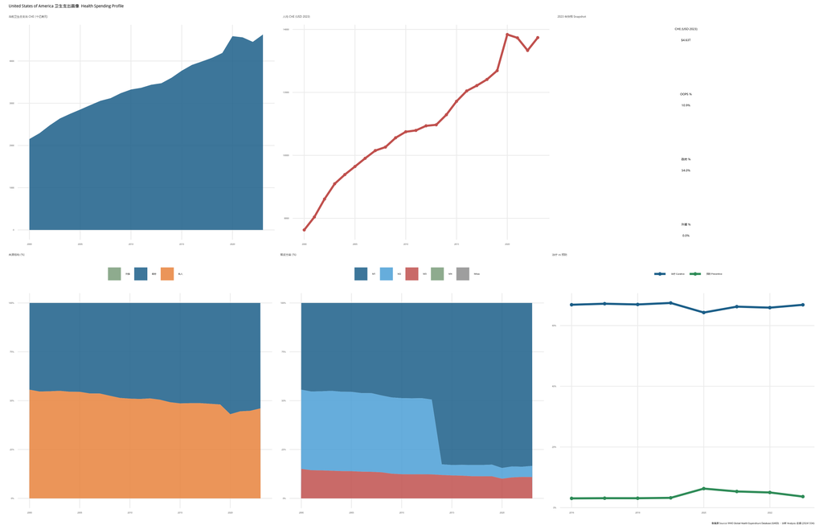

Profile · USA**United States of America · 国家面板**

United States of America · 面板节选 2000 / 2018 / 2023

| 年 | 人均 CHE | CHE 总额 | GGHED % | PVTD % | EXT % | OOPS % | 人口 |
| --- | --- | --- | --- | --- | --- | --- | --- |
| 2,000.00 | 7,629.44 | $2.15T | 44.38 | 55.62 | 0.0000 | 15.12 | $282.16M |
| 2,018.00 | 12,411.00 | $4.08T | 51.60 | 48.40 | 0.0000 | 11.32 | $328.53M |
| 2,023.00 | 13,740.06 | $4.63T | 53.95 | 46.05 | 0.0000 | 10.93 | $336.81M |

IND

### India

Asia · 2000–2023

**人均 CHE***$85***CHE 年化***5.35%***OOPS***43.9%***GGHED***39.0%***EXT***2.4%***人口***$1.44B*

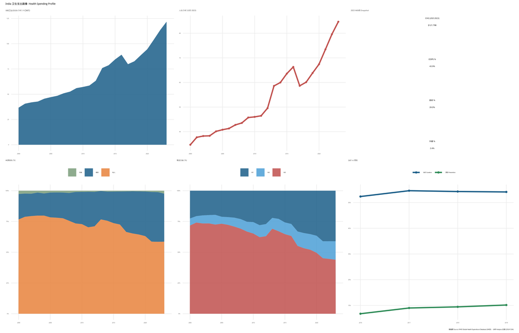

Profile · IND**India · 国家面板**

India · 面板节选 2000 / 2018 / 2023

| 年 | 人均 CHE | CHE 总额 | GGHED % | PVTD % | EXT % | OOPS % | 人口 |
| --- | --- | --- | --- | --- | --- | --- | --- |
| 2,000.00 | 34.69 | $36.70B | 20.68 | 76.64 | 2.68 | 71.70 | $1.06B |
| 2,018.00 | 60.12 | $82.64B | 34.29 | 65.25 | 0.4616 | 53.23 | $1.37B |
| 2,023.00 | 84.69 | $121.79B | 39.02 | 58.56 | 2.41 | 43.89 | $1.44B |

BRA

### Brazil

Americas · 2000–2023

**人均 CHE***$1,010***CHE 年化***2.90%***OOPS***26.2%***GGHED***44.1%***EXT***0.0%***人口***$211.14M*

Brazil · 面板节选 2000 / 2018 / 2023

| 年 | 人均 CHE | CHE 总额 | GGHED % | PVTD % | EXT % | OOPS % | 人口 |
| --- | --- | --- | --- | --- | --- | --- | --- |
| 2,000.00 | 634.89 | $110.48B | 41.64 | 58.05 | 0.3182 | 36.59 | $174.02M |
| 2,018.00 | 922.39 | $190.11B | 41.09 | 58.82 | 0.0854 | 24.83 | $206.11M |
| 2,023.00 | 1,009.84 | $213.22B | 44.13 | 55.85 | 0.0188 | 26.23 | $211.14M |

S30 · Regional Deep Dive

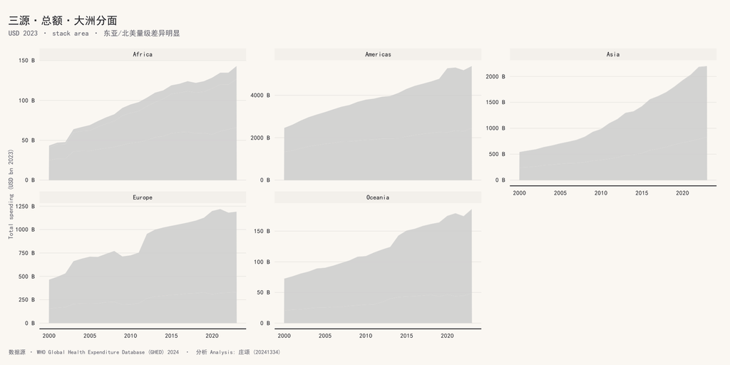

Figure R1 · 大洲流**各大洲 CHE 总量流变 (USD2023)**

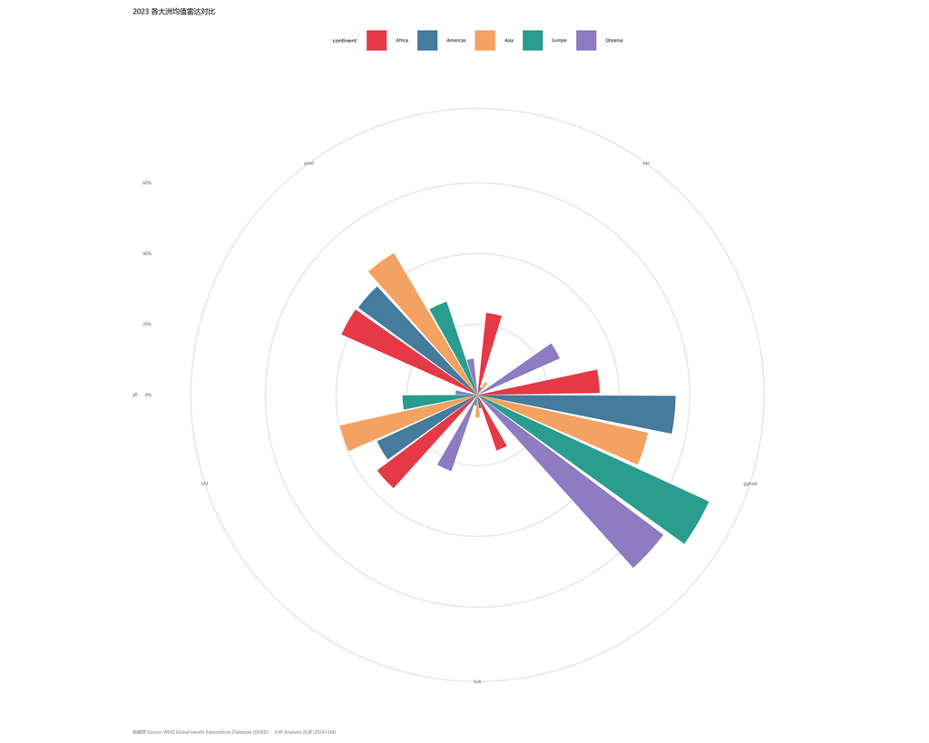

Figure R2 · 大洲雷达**大洲雷达：OOPS / GGHED / PVTD / EXT / CHE_pc**

大洲面板 · 2023

| 大洲 | 国家数 | 人口 | 人均 CHE | OOPS 均值 | GGHED 均值 | EXT 均值 |
| --- | --- | --- | --- | --- | --- | --- |
| Americas | 34.00 | $1.02B | 5,291.52 | 23.69 | 52.24 | 0.6729 |
| Oceania | 16.00 | $44.94M | 4,717.61 | 13.22 | 73.52 | 6.45 |
| Europe | 42.00 | $701.17M | 3,631.18 | 19.71 | 73.01 | 0.0779 |
| Asia | 47.00 | $4.71B | 480.87 | 40.28 | 46.90 | 2.23 |
| Africa | 54.00 | $1.48B | 96.77 | 42.37 | 29.64 | 21.47 |

S40 · Inequality Atlas

## 不平等图册

4 张不同角度的不平等谜言互补：洛伦兹·Gini·偏好kridgeline，同位能与 F3 交叉阅读。

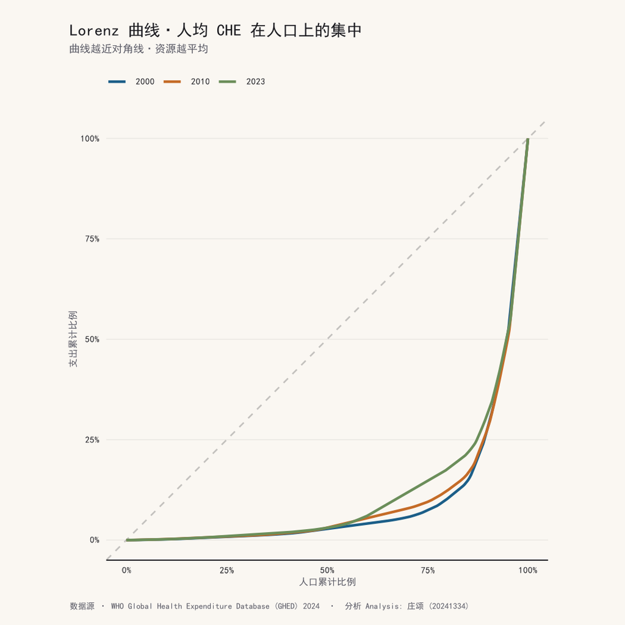

Atlas · equity lorenz**equity lorenz**

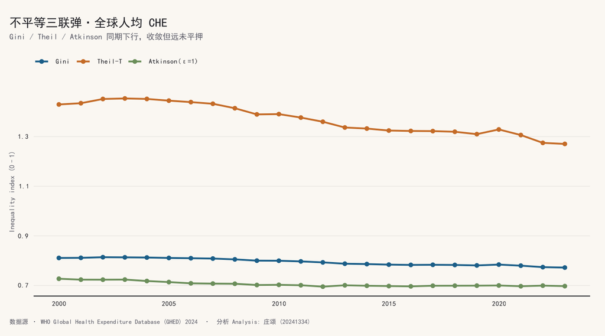

Atlas · equity indices**equity indices**

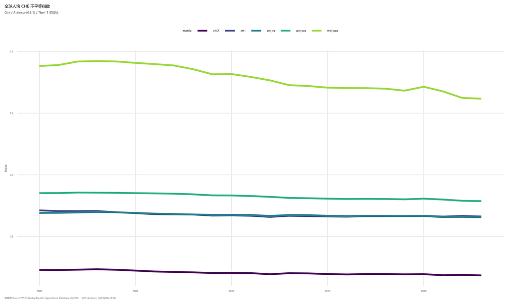

Atlas · inequality timeseries**inequality timeseries**

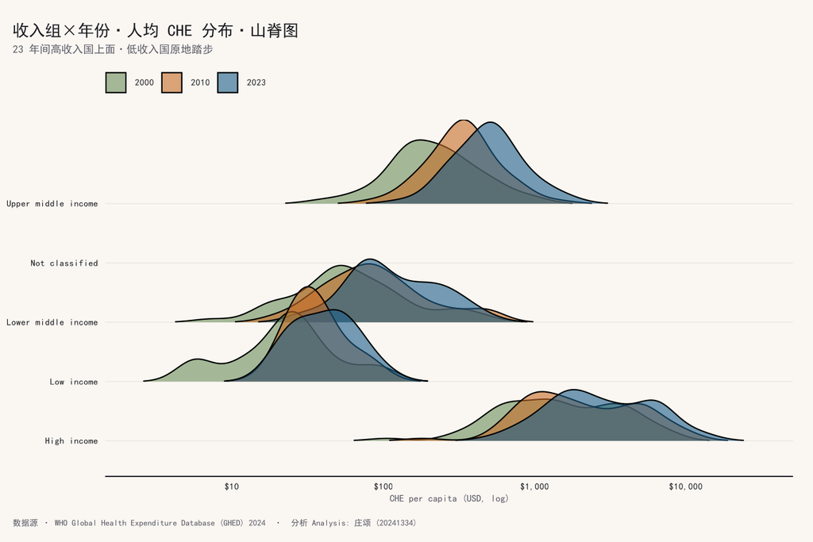

Atlas · combined ridges**combined ridges**

**不平等读图提示**

**洛伦兹曲线：**距对角线越远越不平等；2000 · 2023 二曲线合并呈现 23 年上移。

**Gini / Theil / Atkinson：**三指标同时下降，但 Atkinson(ε=1) 下降最慢。

S50 · Policy Simulator

## 政策仿真器（客户端）

拖动滑块查看：如果全球 OOPS 下降 *Δ<sub>OOPS</sub>* 百分点、GGHED 上升 *Δ<sub>GGHED</sub>* 百分点，预计财务保护在何方。仅为描述性递推，不代表因果。

Δ OOPS（百分点）-5Δ GGHED（百分点）+5Δ EXT（百分点）0

EXT > 20% 国家（估计）**36***基线 36*

仿真逻辑：新的 OOPS = 基线 + ΔOOPS - 0.4 × ΔGGHED； OOPS > 50% 国家数 ≈ 基线 + 1.6 × ΔOOPS - 0.6 × ΔGGHED；EXT > 20% 国家数 ≈ 基线 + 0.5 × ΔEXT。仅为描述性递推，不代表因果。

S60 · Sensitivity

## 稳健性与多规格对比

在不同控变量、子样本、子期限下重拟主结果，估计定性结果对设定的间接依赖。

F5 / F6 主结果的多规格对比

[output not shown]

F6 · 完整面板 FE 表

| term | estimate | std.error | statistic | p.value |
| --- | --- | --- | --- | --- |
| log_gdp_pc | 0.797860 | 0.067275 | 11.8597 | 0.000000 |

F5 · β-收敛面板示例

| iso3_code | continent | log_start | log_end | growth |
| --- | --- | --- | --- | --- |
| ALB | Europe | 5.205 | 6.534 | 0.05776 |
| DZA | Africa | 4.879 | 5.453 | 0.02494 |
| AND | Europe | 7.765 | 8.190 | 0.01850 |
| AGO | Africa | 3.664 | 4.332 | 0.02902 |
| ATG | Americas | 6.726 | 6.735 | 0.00038 |
| ARG | Americas | 6.866 | 7.284 | 0.01820 |
| ARM | Asia | 4.372 | 6.635 | 0.09839 |
| AUS | Oceania | 8.239 | 8.843 | 0.02626 |
| AUT | Europe | 8.385 | 8.740 | 0.01546 |
| AZE | Asia | 4.051 | 5.719 | 0.07254 |
| BHS | Americas | 7.262 | 7.724 | 0.02008 |
| BHR | Asia | 6.845 | 7.065 | 0.00955 |

11 · Gallery

## 静态图表库 · 44 张

按主题筛选；点击任意卡片放大查看原图。

时间**global sources area***53 KB*

指标**oops ranking 2023***120 KB*

分布**oops ridges income***100 KB*

分布**oops box continent***206 KB*

地图**world oops 2023***377 KB*

综合**profile china***193 KB*

综合**profile usa***183 KB*

综合**profile india***194 KB*

时间**covid dumbbell***125 KB*

时间**covid scatter***261 KB*

综合**hc1 vs hc6***205 KB*

时间**oops slope***492 KB*

时间**inequality timeseries***93 KB*

分布**che pc ridges***96 KB*

模型**pca cluster 2022***329 KB*

地图**oops heatmap***153 KB*

结构**continent radar***261 KB*

综合**small multiples***160 KB*

指标**lollipop income***52 KB*

分布**ext density***95 KB*

时间**oops bump***649 KB*

地图**treemap***41 KB*

时间**stream continent***117 KB*

结构**ternary***34 KB*

模型**inequality pca***308 KB*

模型**beta convergence***298 KB*

模型**forecast fan***195 KB*

地图**bivariate map***433 KB*

结构**sankey static***169 KB*

结构**waffle purpose***39 KB*

综合**aid dependency***96 KB*

地图**bivariate oops gov***175 KB*

分布**combined ridges***110 KB*

时间**continent stream***83 KB*

综合**country compare hc***54 KB*

时间**covid dumbbell***99 KB*

模型**efficiency dea***139 KB*

指标**equity indices***64 KB*

指标**equity lorenz***67 KB*

指标**fiscal ghe rank***84 KB*

指标**fiscal ghe share***93 KB*

综合**oops small multiples***148 KB*

模型**outcomes elasticity***289 KB*

时间**slope oops***268 KB*

12 · Interactive lab

## 交互组件 · 24 个独立 HTML

plotly · leaflet · reactable · DT · networkD3。点击 “在右侧查看” 在懒加载 iframe 中打开。

时间

### gapminder animated

5.6 MB · standalone HTML

[新窗打开](https://github.com/2711944586/R/blob/main/分析输出/交互组件/01_gapminder_animated.html)

时间

### highlight ts

4.8 MB · standalone HTML

[新窗打开](https://github.com/2711944586/R/blob/main/分析输出/交互组件/02_highlight_ts.html)

时间

### bar race

4.9 MB · standalone HTML

[新窗打开](https://github.com/2711944586/R/blob/main/分析输出/交互组件/04_bar_race.html)

结构

### ternary

4.8 MB · standalone HTML

[新窗打开](https://github.com/2711944586/R/blob/main/分析输出/交互组件/05_ternary.html)

模型

### forecast subplot

4.8 MB · standalone HTML

[新窗打开](https://github.com/2711944586/R/blob/main/分析输出/交互组件/06_forecast_subplot.html)

指标

### inequality

4.8 MB · standalone HTML

[新窗打开](https://github.com/2711944586/R/blob/main/分析输出/交互组件/07_inequality.html)

地图

### heatmap oops

4.8 MB · standalone HTML

[新窗打开](https://github.com/2711944586/R/blob/main/分析输出/交互组件/08_heatmap_oops.html)

结构

### sankey sources

4.8 MB · standalone HTML

[新窗打开](https://github.com/2711944586/R/blob/main/分析输出/交互组件/09_sankey_sources.html)

时间

### china wb line

4.8 MB · standalone HTML

[新窗打开](https://github.com/2711944586/R/blob/main/分析输出/交互组件/10_china_wb_line.html)

地图

### world leaflet

984 KB · standalone HTML

[新窗打开](https://github.com/2711944586/R/blob/main/分析输出/交互组件/11_world_leaflet.html)

指标

### reactable rank

581 KB · standalone HTML

[新窗打开](https://github.com/2711944586/R/blob/main/分析输出/交互组件/12_reactable_rank.html)

结构

### country network

354 KB · standalone HTML

[新窗打开](https://github.com/2711944586/R/blob/main/分析输出/交互组件/v2_w_country_network.html)

地图

### dt atlas

1.8 MB · standalone HTML

[新窗打开](https://github.com/2711944586/R/blob/main/分析输出/交互组件/v2_w_dt_atlas.html)

时间

### gapminder bubble

5.8 MB · standalone HTML

[新窗打开](https://github.com/2711944586/R/blob/main/分析输出/交互组件/v2_w_gapminder_bubble.html)

时间

### highlight lines

4.8 MB · standalone HTML

[新窗打开](https://github.com/2711944586/R/blob/main/分析输出/交互组件/v2_w_highlight_lines.html)

分布

### income violin

4.8 MB · standalone HTML

[新窗打开](https://github.com/2711944586/R/blob/main/分析输出/交互组件/v2_w_income_violin.html)

地图

### leaflet choropleth

2.3 MB · standalone HTML

[新窗打开](https://github.com/2711944586/R/blob/main/分析输出/交互组件/v2_w_leaflet_choropleth.html)

综合

### mc fan

4.8 MB · standalone HTML

[新窗打开](https://github.com/2711944586/R/blob/main/分析输出/交互组件/v2_w_mc_fan.html)

地图

### oops heatmap

4.8 MB · standalone HTML

[新窗打开](https://github.com/2711944586/R/blob/main/分析输出/交互组件/v2_w_oops_heatmap.html)

指标

### reactable rank

674 KB · standalone HTML

[新窗打开](https://github.com/2711944586/R/blob/main/分析输出/交互组件/v2_w_reactable_rank.html)

结构

### sankey flows

357 KB · standalone HTML

[新窗打开](https://github.com/2711944586/R/blob/main/分析输出/交互组件/v2_w_sankey_flows.html)

模型

### scenarios

4.8 MB · standalone HTML

[新窗打开](https://github.com/2711944586/R/blob/main/分析输出/交互组件/v2_w_scenarios.html)

模型

### splom

4.8 MB · standalone HTML

[新窗打开](https://github.com/2711944586/R/blob/main/分析输出/交互组件/v2_w_splom.html)

结构

### ternary

4.8 MB · standalone HTML

[新窗打开](https://github.com/2711944586/R/blob/main/分析输出/交互组件/v2_w_ternary.html)

**选择左侧任一组件**standalone widget

[interactive chart not shown]

S85 · Glossary & Sources

## 术语表与数据来源

所有缩写·指数·估计器均在此偏表可查。

项目中出现的 12 个关键术语

[output not shown]

### 数据与引用建议

- **WHO GHED** · apps.who.int/nha/database · 主体面板
- **World Bank WDI** · data.worldbank.org · 人口 / GDP / U5MR
- **TidyTuesday** · github.com/rfordatascience/tidytuesday · 2026-04-21 GHS
- **引用：**庄颂. (2026). 全球卫生支出 2000–2023：公平、韧性、未来. 课程项目. github.com/2711944586/R

13 · Reproducibility

## 复现说明 · 一键命令

本项目是单一来源：所有代码、数据、模型、图表都从 `构建.R` 派生。

**克隆仓库**

```bash
git clone https://github.com/2711944586/R.git
```

项目根目录约 700 MB（含图表 + widget + 缓存）。

**安装 R 依赖**

```bash
Rscript 安装依赖.R
```

安装 60+ R 包；网络较慢时设置 CRAN 镜像。

**构建数据缓存**

```bash
Rscript 构建.R data
```

生成 派生数据/处理结果/master_enriched.rds。

**所有图表与交互组件**

```bash
Rscript 构建.R figures
Rscript 构建.R widgets
```

44 张静态图 + 24 个交互组件。

**所有统计模型**

```bash
Rscript 构建.R models
```

Gini · COVID 冲击 · β-收敛 · FE · PCA · 预测。

**一键产出本页与 GitHub Pages 首页**

```bash
Rscript 构建.R submission
```

生成 课程提交/庄颂_20241334.html 与 网站发布/index.html。

**启动仔表盘**

```bash
Rscript 启动仪表盘.R 4848
```

本地 Shiny 仪表盘（12 个模块）。

**一键部署包**

```bash
Rscript 构建.R deploy
```

Quarto 章节 + shinylive + 整合首页 + widget assets。

S90b · Session

## 运行环境与依赖版本

本页生成时的 R / OS / 主要 R 包版本快照，用于复现口径。

- R 4.5.2
- Platform: x86_64-w64-mingw32
- 生成时间：2026-05-09 22:14:09 CST
- **ggplot2** 4.0.2
- **plotly** 4.12.0
- **leaflet** 2.2.3
- **reactable** 0.4.5
- **DT** 0.34.0
- **fixest** 0.14.1
- **forecast** 9.0.2
- **shiny** 1.13.0
- **showtext** 0.9.7
- **sf** 1.1.1
- **rnaturalearth** 1.2.0
- **countrycode** 1.8.0
- **wbstats** 1.1
- **base64enc** 0.1.6
- **htmlwidgets** 1.6.4

14 · Conclusion

## 结论与政策建议

1

### 把 OOPS 列为韧性的第一指标

32 个国家在 2023 年仍有 OOPS > 50%，任一冲击均会推高因病致贫率。在国家卫生战略中把 OOPS 增量作为*反向 KPI*。

2

### 提高 GGHED 是降 OOPS 的主可控变量

F2 已显示 GGHED 与 OOPS 高度负相关；在中低收入国家应优先扩大社保基金 + 一般税池子。

3

### 保留反周期卫生缓冲

F4 表明，在 COVID 冲击下，能主动加码 GGHED 的国家把 OOPS 压住了；财政纪律要为危机保留缓冲。

4

### 追赶非自动：β-收敛但分大洲异质

F5 中 β < 0 但半收敛年差异巨大；非洲国家需持续 GGHED 投入 + 外援。

5

### 用 archetype 分类对症施策

F7 的 4 类国家筹资 archetype 提供了可执行的政策路径：政府主导 / 私人保险 / 自付驱动 / 外援依赖。

6

### 预测应作为政策对话的起点

F8 的 ARIMA 仅外推趋势；下一步是结合 Shiny 仪表盘做情景推演。

### 研究局限

- OOPS 与外援的口径在不同国家存在统计差异。
- 2023 年部分国家数据来自模型估计，需以新版 GHED 公布为准。
- 面板 FE 不能识别因果，仅给出条件相关。